# TCox: correlation-based regularization applied to colorectal cancer

Carolina Peixoto, Marta B. Lopes, Marta Martins, Luís Costa and Susana Vinga

September, 2020

# 1 Install packages and functions

## 1.1 Required libraries

```r
library(SummarizedExperiment)
library(dplyr)
library(DT)
library(tidyverse)
library(futile.logger)
library(loose.rock)
library(survival)
library(GGally)
library(ggplot2)
library(glmnet)
library(glmSparseNet)
library(gplots)
library(readr)
library(maftools)
library(RTCGAToolbox)
library(edgeR)
```

## 1.2 Functions

```r
twiner_glmnet <- function (x,y,alpha, w) {
                      cv.glmnet(as.matrix(x),as.matrix(y),
                               family = 'cox',foldid = my_foldid, penalty.factor = w,
                               alpha = alpha,
                               nlambda = 100,
                               #lambda.min.ratio = 10^(-2),
                               nfolds= 10)
}

twiner_coefs <- function (cv.fit){
  coef(cv.fit, s = 'lambda.min')[,1] %>% { .[. != 0]}
}


twiner_genes <- function (cv.fit) {
  b <- which(cv.fit$glmnet.fit$beta[,which(cv.fit$cvm == min(cv.fit$cvm))] != 0)
  return (names(b))
}

train <- function (coefs) {
  separate2GroupsCox(as.vector(coefs),
                               xdata.train[, names(coefs)],
                               ydata.train,
                               plot.title = 'Train Set TCox', legend.outside = FALSE)
}

test <- function (coefs) {
  separate2GroupsCox(as.vector(coefs),
                               xdata.test[, names(coefs)],
                               ydata.test,
                               plot.title = 'Test Set TCox', legend.outside = FALSE)
}

all <- function (coefs) {
  separate2GroupsCox(as.vector(coefs),
                               xdata[, names(coefs)],
                               ydata,
                               plot.title = 'all Set TCox', legend.outside = FALSE)
}
```

# 2 Download and prepare dataframes from TCGA - RTCGAtoolbox package

## 2.1 Colorectal samples RNASeq data

Download COAD dataset

```r
coadData <- getFirehoseData(dataset="COAD", runDate="20150402",
    forceDownload=TRUE, clinical=TRUE, RNASeq2GeneNorm=TRUE)

rnaseq1 <- coadData@RNASeq2GeneNorm[[2]]
rnaseq1 <- rnaseq1@DataMatrix
rnaseq1 <- t(rnaseq1)
```

```r
rnaseq1 <- as.data.frame(rnaseq1)


rnaseq1$names <- rownames(rnaseq1)


dim(rnaseq1) #328
```

```
## [1]   328 20502
```

```r
#keep only tumor samples
tumor <- rnaseq1 %>%
  filter(str_detect(names, "01A"))

dim(tumor) #287
```

```
## [1]   282 20502
```

```r
tumor$names <- str_sub(tumor$names, 1, str_length(tumor$names)-16) #put names in the right format
#remove duplicated rows
tumor <- tumor[!duplicated(tumor$names), ]
rownames(tumor) <- tumor$names
tumor <- tumor[,-20502]

normal <- rnaseq1 %>%
  filter(!str_detect(names, "01A"))

dim(normal) #287
```

```
## [1]    46 20502
```

```r
normal$names <- str_sub(normal$names, 1, str_length(normal$names)-16) #put names in the right format
normal <- normal[!duplicated(normal$names), ]
rownames(normal) <- normal$names
normal <- normal[,-20502]
```

Download READ dataset

```r
readData <- getFirehoseData(dataset="READ", runDate="20150402",
    forceDownload=TRUE, clinical=TRUE, RNASeq2GeneNorm=TRUE)

rnaseq2 <- readData@RNASeq2GeneNorm[[2]]
rnaseq2 <- rnaseq2@DataMatrix
rnaseq2 <- t(rnaseq2)
```

```r
rnaseq2 <- as.data.frame(rnaseq2)


rnaseq2$names <- rownames(rnaseq2)


dim(rnaseq2) #328
```

```
## [1]   105 20502
```

```r
#keep only tumor samples
tumorread <- rnaseq2 %>%
  filter(str_detect(names, "01A"))

dim(tumorread) #287
```

```
## [1]    91 20502
```

```r
tumorread$names <- str_sub(tumorread$names, 1, str_length(tumorread$names)-16) #put names in the right format
#remove duplicated rows
tumorread <- tumorread[!duplicated(tumorread$names), ]
rownames(tumorread) <- tumorread$names
tumorread <- tumorread[,-20502]

normalread <- rnaseq2 %>%
  filter(!str_detect(names, "01A"))

dim(normalread) #287
```

```
## [1]    14 20502
```

```r
normalread$names <- str_sub(normalread$names, 1, str_length(normalread$names)-16) #put names in the right format
normalread <- normalread[!duplicated(normalread$names), ]
rownames(normalread) <- normalread$names
normalread <- normalread[,-20502]
```

Colorectal dataset

```r
dim(tumor)
```

```
## [1]   282 20501
```

```r
dim(normal)
```

```
## [1]    46 20501
```

```r
dim(tumorread)
```

```
## [1]    91 20501
```

```r
dim(normalread)
```

```
## [1]    14 20501
```

```r
tumorf <- rbind(tumor,tumorread)
dim(tumorf)
```

```
## [1]   373 20501
```

```r
normalf <- rbind(normal, normalread)
dim(normalf)
```

```
## [1]    60 20501
```

```r
# write.table(tumorf, "crcRNAseq.txt")
# write.table(normalf, "normalRNAseq.txt")
```

## 2.2 Clinical data

COAD

```r
clinic <- coadData@clinical

clinic.data <- clinic[,3:5]
clinic.data$days_to_death[is.na(clinic.data$days_to_death)] <- 0

for (i in 1:nrow(clinic.data)){

  if (clinic.data$days_to_death[i] != 0){

    clinic.data$days_to_last_followup[i] <- 0

  }

datasurv <- apply(as.matrix(clinic.data),2,as.numeric)
datasurv <- as.data.frame(datasurv)
datasurv$time <- datasurv$days_to_death + datasurv$days_to_last_followup

datasurv <- datasurv[,-c(2,3)]
rownames(datasurv) <- rownames(clinic.data)
datasurv <- datasurv[datasurv$time > 0, ]
datasurv <- na.omit(datasurv)
colnames(datasurv) <- c("status","time")

datasurv$names <- rownames(datasurv)
datasurv$names <- toupper(datasurv$names)
datasurv$names <- chartr('.', '-', datasurv$names)

rownames(datasurv) <- datasurv$names
datasurv <- datasurv[,-3]
}
```

READ

```r
clinicread <- readData@clinical

clinicread.data <- clinicread[,3:5]
clinicread.data$days_to_death[is.na(clinicread.data$days_to_death)] <- 0

for (i in 1:nrow(clinicread.data)){

  if (clinicread.data$days_to_death[i] != 0){

    clinicread.data$days_to_last_followup[i] <- 0

  }

datasurvread <- apply(as.matrix(clinicread.data),2,as.numeric)
datasurvread <- as.data.frame(datasurvread)
datasurvread$time <- datasurvread$days_to_death + datasurvread$days_to_last_followup

datasurvread <- datasurvread[,-c(2,3)]
rownames(datasurvread) <- rownames(clinicread.data)
datasurvread <- datasurvread[datasurvread$time > 0, ]
datasurvread <- na.omit(datasurvread)
colnames(datasurvread) <- c("status","time")

datasurvread$names <- rownames(datasurvread)
datasurvread$names <- toupper(datasurvread$names)
datasurvread$names <- chartr('.', '-', datasurvread$names)

rownames(datasurvread) <- datasurvread$names
datasurvread <- datasurvread[,-3]
}
```

Colorectal

```r
dim(datasurv)
```

```
## [1] 436   2
```

```r
dim(datasurvread)
```

```
## [1] 159   2
```

```r
datasurvf <- rbind(datasurv,datasurvread)
dim(datasurvf)
```

```
## [1] 595   2
```

# 3 TCox

## 3.1 using both normal and tumor data from TCGA

- removing variables with sd=0

```r
xcoad_sd <- tumorf [,sapply(seq(ncol(tumorf)), function(ix) {sd(tumorf[,ix])}) != 0] # 328 20025
xnormal_sd <- normalf[,sapply(seq(ncol(normalf)), function(ix) {sd(normalf[,ix])}) != 0] #345 48710

xcoad_less <- xcoad_sd[,which(colnames(xcoad_sd) %in% colnames(xnormal_sd))]
xnormal_less <- xnormal_sd[,which(colnames(xnormal_sd) %in% colnames(xcoad_sd))]

# normalizing data
xcoad_norm <- scale(log2(xcoad_less+1))
xnorm_norm <- scale(log2(xnormal_less+1))
```

- weight vector that penalizes genes with smaller distances between tumor and normal correlation matrices

```r
## correlation matrices

library("propagate")
library("lsa")

options(fftempdir = "~/")

xtumoral_cor <- bigcor(xcoad_norm, y = NULL, fun = "cor", size = 2000, verbose=FALSE)
xtumoral_cor <- as.data.frame(as.ffdf(xtumoral_cor))

xnormal_cor <- bigcor(xnorm_norm, y = NULL, fun = "cor", size = 2000, verbose=FALSE)
xnormal_cor <- as.data.frame(as.ffdf(xnormal_cor))

# angular distance
ang_weight <- vector()

for (i in 1:dim(xcoad_norm)[2]){
ang_weight[i] <- acos(cosine(xtumoral_cor[,i],xnormal_cor[,i]))/pi
}
```

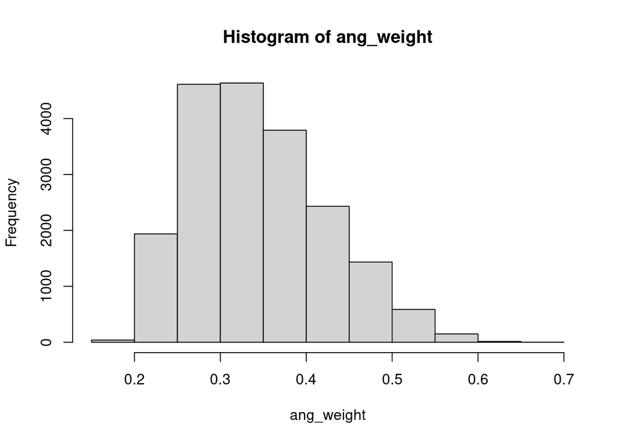

```r
##normalized weights (between 0 and 1)

tumornormal_weights <- ang_weight / max(ang_weight)
hist(ang_weight)
```

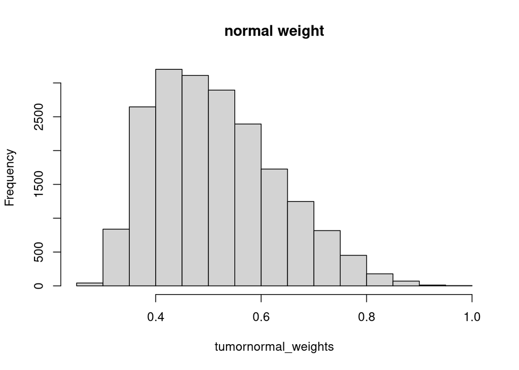

```r
hist(tumornormal_weights,main="normal weight")
```

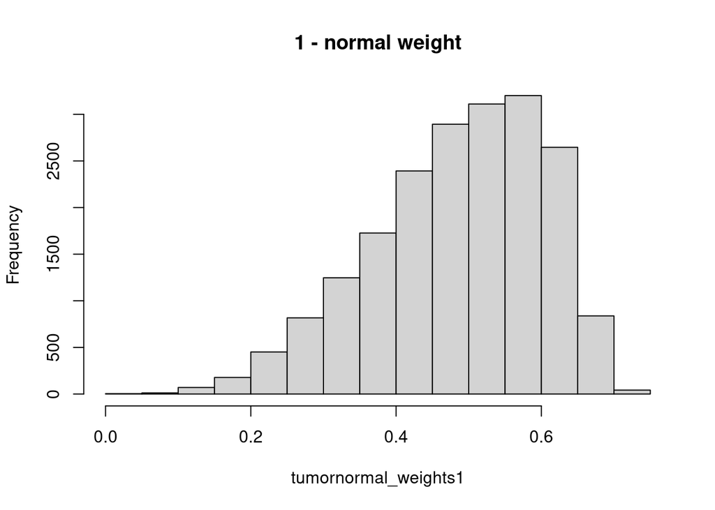

```r
#1-w
tumornormal_weights1 <- 1 - tumornormal_weights
hist(tumornormal_weights1,main="1 - normal weight")
```

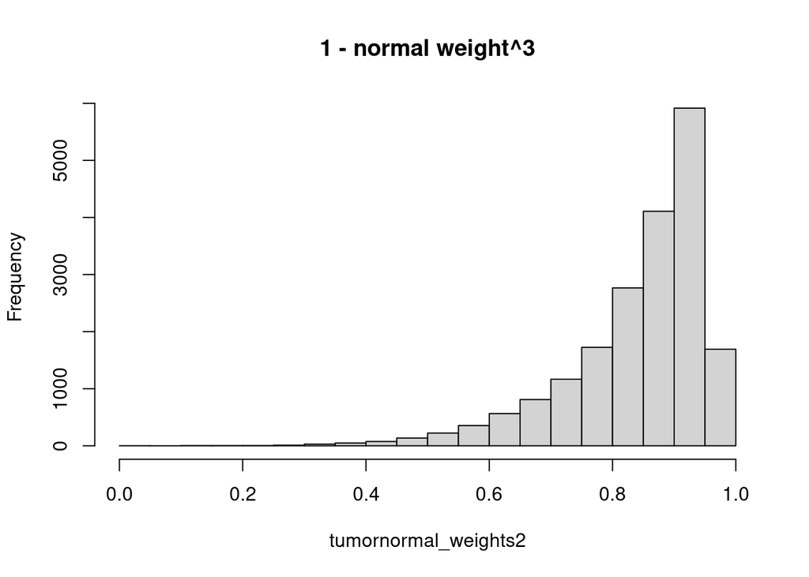

```r
#1-w^3
tumornormal_weights2 <- 1 - (tumornormal_weights^3)
hist(tumornormal_weights2,main="1 - normal weight^3")
```

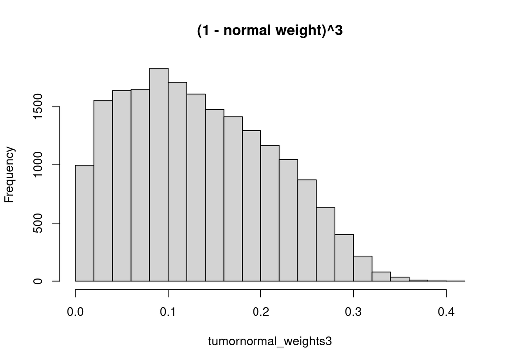

```r
#(1-w)^3
tumornormal_weights3 <- (1 - tumornormal_weights)^3
hist(tumornormal_weights3,main="(1 - normal weight)^3")
```

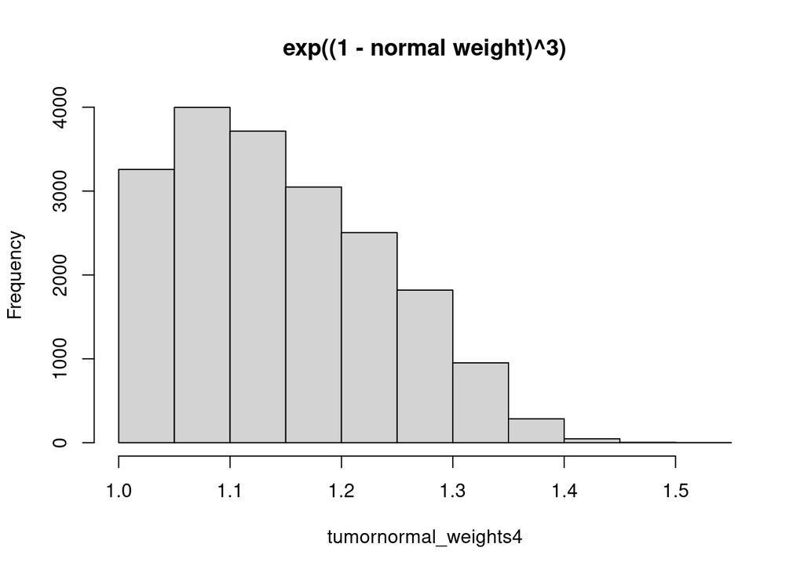

```r
#exp((1-w)^3)
tumornormal_weights4 <- exp((1 - tumornormal_weights)^3)
hist(tumornormal_weights4,main="exp((1 - normal weight)^3)")
```

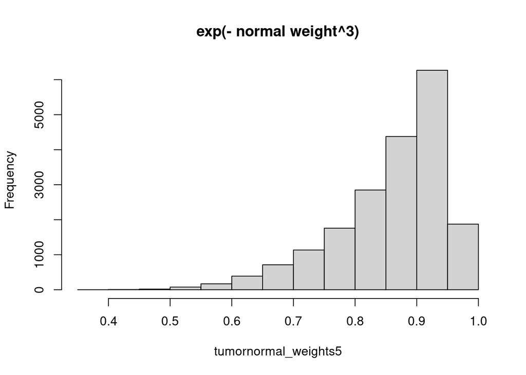

```r
#exp(-w^3)
tumornormal_weights5 <- exp(- tumornormal_weights^3)
hist(tumornormal_weights5,main="exp(- normal weight^3)")
```

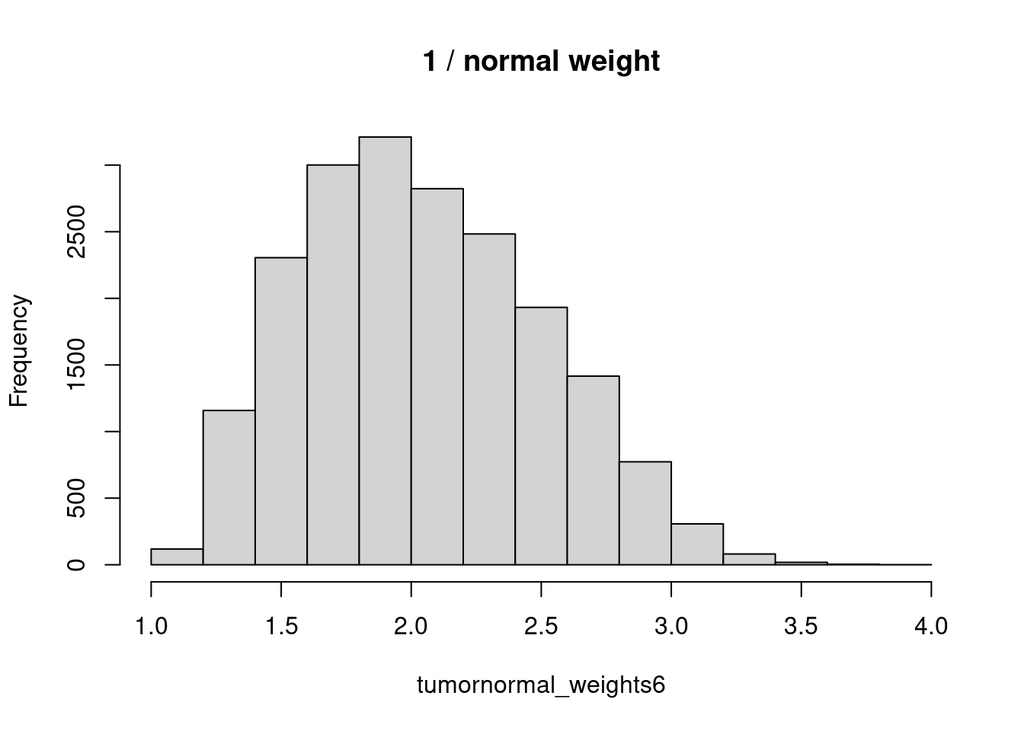

```r
#1/w
tumornormal_weights6 <- 1 / tumornormal_weights
hist(tumornormal_weights6,main="1 / normal weight")
```

## 3.2 Analyse different weight vectores:

```r
xdata.raw <- as.data.frame(xcoad_less) #255 19525

ydata.raw <- as.data.frame(datasurvf)
ydata.raw$rownames <- rownames(ydata.raw)
ydata.raw$rownames <- chartr('.', '-', ydata.raw$rownames)
rownames(ydata.raw) <- ydata.raw$rownames
ydata <- ydata.raw[rownames(ydata.raw) %in%
                              rownames(xdata.raw),]


xdata.raw <- xdata.raw[rownames(xdata.raw) %in%
                         rownames(ydata),]
xdata <- xdata.raw %>%
  { (apply(., 2, sd) != 0) } %>%
  { xdata.raw[, .] } %>%
  scale

xdata <- as.matrix(xdata) #293 17910

ydata <- ydata[,1:2]
dim(xdata)
```

```
## [1]   357 19630
```

Test / Training sets

```r
set.seed(params$seed)
ixs <- loose.rock::balanced.train.and.test(which(as.logical(ydata$status)), which(as.logical(!ydata$status)), train.perc = params$train)
xdata.test <- xdata[ixs$test,]
ydata.test <- ydata[ixs$test,]
#
xdata.train <- xdata[ixs$train,]
ydata.train <- ydata[ixs$train,]

xdata.train.digest <- loose.rock::digest.cache(xdata.train)

flog.info('Size of sets: (size/events)\n * Training set: % 4d/% 4d\n * Test set:     % 4d/% 4d',
          nrow(xdata.train),
          sum(ydata.train$status),
          nrow(xdata.test),
          sum(ydata.test$status))
```

```
## INFO [2020-09-14 15:18:18] Size of sets: (size/events)
##  * Training set:  249/  50
##  * Test set:      108/  22
```

```r
 # * Training set:  204/  50
 # * Test set:       89/  22

#Foldid
my_foldid <- sample(1:10,size=dim(ydata.train)[1],replace=TRUE)


#Remove columns with standard deviation of zero
xdata.train <- xdata.train[, ! apply(xdata.train , 2 , function(x) sd(x, na.rm = TRUE)==0 ) ]

xdata.test <- xdata.test[, ! apply(xdata.test , 2 , function(x) sd(x, na.rm = TRUE)==0 ) ]

dim(xdata.test)
```

```
## [1]   108 19572
```

```r
dim(xdata.train)
```

```
## [1]   249 19618
```

```r
xdata.train <- xdata.train[,colnames(xdata.train) %in%
                         colnames(xdata.test)]
xdata.test <- xdata.test[,colnames(xdata.test) %in%
                         colnames(xdata.train)]

dim(xdata.test)
```

```
## [1]   108 19560
```

```r
dim(xdata.train)
```

```
## [1]   249 19560
```

```r
xdata.train[1:3,1:3]
```

```
##                     A1BG        A1CF       A2BP1
## TCGA-3L-AA1B -0.09037123  0.50178233 -0.29147700
## TCGA-4N-A93T  6.56494274 -0.65736676  0.03499383
## TCGA-4T-AA8H -0.14165161  0.04934209 -0.36260403
```

### 3.2.1 1/w

#### 3.2.1.1 0.3

```r
#glmnet
cv.fit_twii3 <- twiner_glmnet(xdata.train,ydata.train,0.3, tumornormal_weights6)


#genes
coefs.v_twii3 <- twiner_coefs(cv.fit_twii3)

fit.selected_twii3 <- twiner_genes(cv.fit_twii3)
length(fit.selected_twii3)
```

```
## [1] 10
```

```r
#train
train_twii03 <- train (coefs.v_twii3)
train_twii03$pvalue ## these values are the ones in Table 1
```

```
## [1] 0.002401583
```

```r
#test
test_twii03 <- test (coefs.v_twii3)
test_twii03$pvalue
```

```
## [1] 0.07566096
```

```r
#all
all_twii03 <- all (coefs.v_twii3)
```

#### 3.2.1.2 0.2

```r
#glmnet
cv.fit_twii2 <- twiner_glmnet(xdata.train,ydata.train,0.2, tumornormal_weights6)


#genes
coefs.v_twii2 <- twiner_coefs(cv.fit_twii2)

fit.selected_twii2 <- twiner_genes(cv.fit_twii2)
length(fit.selected_twii2)
```

```
## [1] 11
```

```r
fit.selected_twii2
```

```
##  [1] "C10orf114" "CARKD"     "FAM159A"   "IFT74"     "LOC285780" "LOC646498"
##  [7] "OSBPL3"    "PAX5"      "PCDHB12"   "PRCD"      "TRIM67"
```

```r
#train
train_twii02 <- train (coefs.v_twii2)
train_twii02$pvalue
```

```
## [1] 0.0005882518
```

```r
#test
test_twii02 <- test (coefs.v_twii2)
test_twii02$pvalue
```

```
## [1] 0.06653314
```

```r
#all
all_twii02 <- all (coefs.v_twii2)
```

#### 3.2.1.3 0.1

```r
#glmnet
cv.fit_twii1 <- twiner_glmnet(xdata.train,ydata.train,0.1, tumornormal_weights6)

#genes
coefs.v_twii1 <- twiner_coefs(cv.fit_twii1)

fit.selected_twii1 <- twiner_genes(cv.fit_twii1)
length(fit.selected_twii1)
```

```
## [1] 53
```

```r
fit.selected_twii1
```

```
##  [1] "ANKRD26P1"    "AOX2P"        "ASPHD1"       "C10orf114"    "C20orf106"
##  [6] "CAPN7"        "CARKD"        "CLDN9"        "COL19A1"      "COX4I2"
## [11] "CUZD1"        "CYP27C1"      "CYP7A1"       "DCLK3"        "DCP1A"
## [16] "DPPA2"        "EEPD1"        "FAM138B"      "FAM159A"      "FCRL2"
## [21] "FLJ16779"     "GRAPL"        "HPCAL1"       "IFT74"        "IGLON5"
## [26] "LBX2"         "LOC100303728" "LOC285074"    "LOC285780"    "LOC646498"
## [31] "LOC732275"    "MEIG1"        "NKAIN4"       "NXF2B"        "OR2T5"
## [36] "OSBPL3"       "OSTN"         "PAX5"         "PCDHA7"       "PCDHB12"
## [41] "PGAM2"        "PRCD"         "RAB20"        "SEPT7P2"      "SNTG1"
## [46] "TAC3"         "TERF2IP"      "TRIM67"       "TXNL4B"       "WBSCR27"
## [51] "ZDHHC19"      "ZNF607"       "ZNF883"
```

```r
#train
train_twii01 <- train (coefs.v_twii1)
train_twii01$pvalue
```

```
## [1] 2.664447e-09
```

```r
#test
test_twii01 <- test (coefs.v_twii1)
test_twii01$pvalue
```

```
## [1] 0.01944886
```

```r
#all
all_twii01 <- all (coefs.v_twii1)
```

#### 3.2.1.4 0.05

```r
#glmnet
cv.fit_twii05 <- twiner_glmnet(xdata.train,ydata.train,0.05, tumornormal_weights6)

#genes
coefs.v_twii05 <- twiner_coefs(cv.fit_twii05)

fit.selected_twii05 <- twiner_genes(cv.fit_twii05)
length(fit.selected_twii05)
```

```
## [1] 96
```

```r
#train
train_twii05 <- train (coefs.v_twii05)

#test
test_twii05 <- test (coefs.v_twii05)

#all
all_twii05 <- all (coefs.v_twii05)
```

#### 3.2.1.5 plot

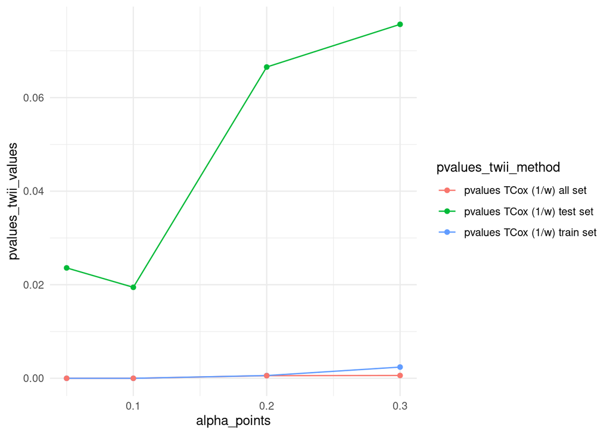

```r
alpha_points<-c(0.3, 0.2,0.1,0.05)

pvalues_twii_values_train<-c(train_twii03$pvalue,train_twii02$pvalue,train_twii01$pvalue,train_twii05$pvalue)

pvalues_twii_values_test<-c(test_twii03$pvalue,test_twii02$pvalue,test_twii01$pvalue,test_twii05$pvalue)

pvalues_twii_values_all<-c(all_twii03$pvalue,all_twii02$pvalue,all_twii01$pvalue,all_twii05$pvalue)



pvalues_twii_values<-c(train_twii03$pvalue,train_twii02$pvalue,train_twii01$pvalue,train_twii05$pvalue,test_twii03$pvalue,test_twii02$pvalue,test_twii01$pvalue,test_twii05$pvalue,all_twii03$pvalue,all_twii02$pvalue,all_twii01$pvalue,all_twii05$pvalue)



pvalues_twii_method<-c(rep("pvalues TCox (1/w) train set",4),rep("pvalues TCox (1/w) test set",4),rep("pvalues TCox (1/w) all set",4))




pvalues_twii<-data.frame(alpha_points,pvalues_twii_values,pvalues_twii_method)
p_pvalues_twii<-ggplot(data = pvalues_twii, aes(x = alpha_points, y = pvalues_twii_values,color= pvalues_twii_method)) + geom_line()+geom_point()+theme_minimal()
p_pvalues_twii+ ylim(0, max(pvalues_twii_values))
```

### 3.2.2 exp(-w^3)

#### 3.2.2.1 0.3

```r
#glmnet
cv.fit_twexp23 <- twiner_glmnet(xdata.train,ydata.train,0.3, tumornormal_weights5)


#genes
coefs.v_twexp23 <- twiner_coefs(cv.fit_twexp23)

fit.selected_twexp23 <- twiner_genes(cv.fit_twexp23)
length(fit.selected_twexp23)
```

```
## [1] 12
```

```r
#train
train_twexp203 <- train (coefs.v_twexp23)
train_twexp203$pvalue ## these values are the ones in Table 1
```

```
## [1] 0.0006276918
```

```r
#test
test_twexp203 <- test (coefs.v_twexp23)
test_twexp203$pvalue
```

```
## [1] 0.4244
```

```r
#all
all_twexp203 <- all (coefs.v_twexp23)
```

#### 3.2.2.2 0.2

```r
#glmnet
cv.fit_twexp22 <- twiner_glmnet(xdata.train,ydata.train,0.2, tumornormal_weights5)


#genes
coefs.v_twexp22 <- twiner_coefs(cv.fit_twexp22)

fit.selected_twexp22 <- twiner_genes(cv.fit_twexp22)
length(fit.selected_twexp22)
```

```
## [1] 18
```

```r
#train
train_twexp202 <- train (coefs.v_twexp22)

#test
test_twexp202 <- test (coefs.v_twexp22)

#all
all_twexp202 <- all (coefs.v_twexp22)
```

#### 3.2.2.3 0.1

```r
#glmnet
cv.fit_twexp21 <- twiner_glmnet(xdata.train,ydata.train,0.1, tumornormal_weights5)

#genes
coefs.v_twexp21 <- twiner_coefs(cv.fit_twexp21)

fit.selected_twexp21 <- twiner_genes(cv.fit_twexp21)
length(fit.selected_twexp21)
```

```
## [1] 44
```

```r
#train
train_twexp201 <- train (coefs.v_twexp21)

#test
test_twexp201 <- test (coefs.v_twexp21)

#all
all_twexp201 <- all (coefs.v_twexp21)
```

#### 3.2.2.4 0.05

```r
#glmnet
cv.fit_twexp205 <- twiner_glmnet(xdata.train,ydata.train,0.05, tumornormal_weights5)

#genes
coefs.v_twexp205 <- twiner_coefs(cv.fit_twexp205)

fit.selected_twexp205 <- twiner_genes(cv.fit_twexp205)
length(fit.selected_twexp205)
```

```
## [1] 72
```

```r
#train
train_twexp205 <- train (coefs.v_twexp205)

#test
test_twexp205 <- test (coefs.v_twexp205)

#all
all_twexp205 <- all (coefs.v_twexp205)
```

#### 3.2.2.5 plot

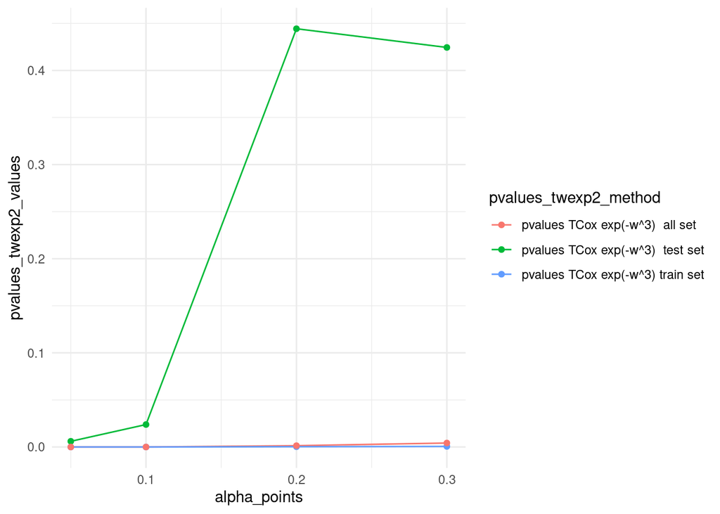

```r
alpha_points<-c(0.3, 0.2,0.1,0.05)

pvalues_twexp2_values_train<-c(train_twexp203$pvalue,train_twexp202$pvalue,train_twexp201$pvalue,train_twexp205$pvalue)

pvalues_twexp2_values_test<-c(test_twexp203$pvalue,test_twexp202$pvalue,test_twexp201$pvalue,test_twexp205$pvalue)

pvalues_twexp2_values_all<-c(all_twexp203$pvalue,all_twexp202$pvalue,all_twexp201$pvalue,all_twexp205$pvalue)



pvalues_twexp2_values<-c(train_twexp203$pvalue,train_twexp202$pvalue,train_twexp201$pvalue,train_twexp205$pvalue,test_twexp203$pvalue,test_twexp202$pvalue,test_twexp201$pvalue,test_twexp205$pvalue,all_twexp203$pvalue,all_twexp202$pvalue,all_twexp201$pvalue,all_twexp205$pvalue)



pvalues_twexp2_method<-c(rep("pvalues TCox exp(-w^3) train set",4),rep("pvalues TCox exp(-w^3)  test set",4),rep("pvalues TCox exp(-w^3)  all set",4))




pvalues_twexp2<-data.frame(alpha_points,pvalues_twexp2_values,pvalues_twexp2_method)
p_pvalues_twexp2<-ggplot(data = pvalues_twexp2, aes(x = alpha_points, y = pvalues_twexp2_values,color= pvalues_twexp2_method)) + geom_line()+geom_point()+theme_minimal()
p_pvalues_twexp2+ ylim(0, max(pvalues_twexp2_values))
```

### 3.2.3 1-W

#### 3.2.3.1 0.3

```r
#glmnet
cv.fit_tw1i3 <- twiner_glmnet(xdata.train,ydata.train,0.3, tumornormal_weights1)


#genes
coefs.v_tw1i3 <- twiner_coefs(cv.fit_tw1i3)

fit.selected_tw1i3 <- twiner_genes(cv.fit_tw1i3)
length(fit.selected_tw1i3)
```

```
## [1] 23
```

```r
#train
train_tw1i03 <- train (coefs.v_tw1i3)

#test
test_tw1i03 <- test (coefs.v_tw1i3)

#all
all_tw1i03 <- all (coefs.v_tw1i3)
```

#### 3.2.3.2 0.2

```r
#glmnet
cv.fit_tw1i2 <- twiner_glmnet(xdata.train,ydata.train,0.2, tumornormal_weights1)


#genes
coefs.v_tw1i2 <- twiner_coefs(cv.fit_tw1i2)

fit.selected_tw1i2 <- twiner_genes(cv.fit_tw1i2)
length(fit.selected_tw1i2)
```

```
## [1] 28
```

```r
#train
train_tw1i02 <- train (coefs.v_tw1i2)

#test
test_tw1i02 <- test (coefs.v_tw1i2)

#all
all_tw1i02 <- all (coefs.v_tw1i2)
```

#### 3.2.3.3 0.1

```r
#glmnet
cv.fit_tw1i1 <- twiner_glmnet(xdata.train,ydata.train,0.1, tumornormal_weights1)

#genes
coefs.v_tw1i1 <- twiner_coefs(cv.fit_tw1i1)

fit.selected_tw1i1 <- twiner_genes(cv.fit_tw1i1)
length(fit.selected_tw1i1)
```

```
## [1] 36
```

```r
#train
train_tw1i01 <- train (coefs.v_tw1i1)

#test
test_tw1i01 <- test (coefs.v_tw1i1)

#all
all_tw1i01 <- all (coefs.v_tw1i1)
```

#### 3.2.3.4 0.05

```r
#glmnet
cv.fit_tw1i05 <- twiner_glmnet(xdata.train,ydata.train,0.05, tumornormal_weights1)

#genes
coefs.v_tw1i05 <- twiner_coefs(cv.fit_tw1i05)

fit.selected_tw1i05 <- twiner_genes(cv.fit_tw1i05)
length(fit.selected_tw1i05)
```

```
## [1] 47
```

```r
#train
train_tw1i05 <- train (coefs.v_tw1i05)

#test
test_tw1i05 <- test (coefs.v_tw1i05)

#all
all_tw1i05 <- all (coefs.v_tw1i05)
```

#### 3.2.3.5 plot

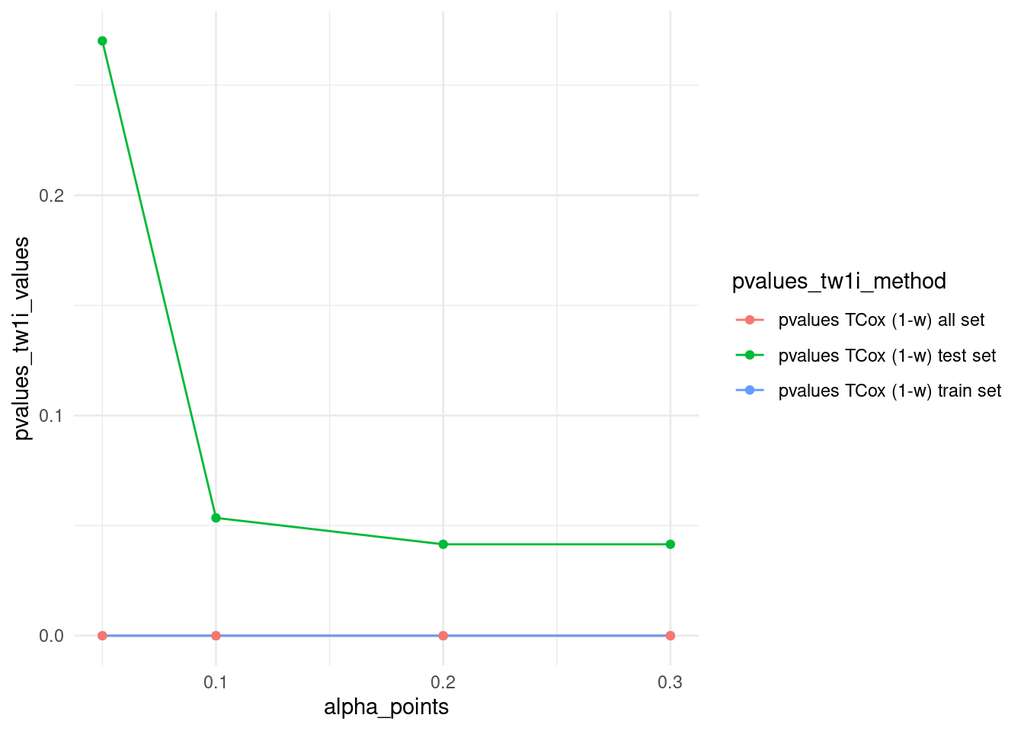

```r
alpha_points<-c(0.3,0.2,0.1,0.05)

pvalues_tw1i_values_train<-c(train_tw1i03$pvalue,train_tw1i02$pvalue,train_tw1i01$pvalue,train_tw1i05$pvalue)

pvalues_tw1i_values_test<-c(test_tw1i03$pvalue,test_tw1i02$pvalue,test_tw1i01$pvalue,test_tw1i05$pvalue)

pvalues_tw1i_values_all<-c(all_tw1i03$pvalue,all_tw1i02$pvalue,all_tw1i01$pvalue,all_tw1i05$pvalue)



pvalues_tw1i_values<-c(train_tw1i03$pvalue,train_tw1i02$pvalue,train_tw1i01$pvalue,train_tw1i05$pvalue,test_tw1i03$pvalue,test_tw1i02$pvalue,test_tw1i01$pvalue,test_tw1i05$pvalue,all_tw1i03$pvalue,all_tw1i02$pvalue,all_tw1i01$pvalue,all_tw1i05$pvalue)



pvalues_tw1i_method<-c(rep("pvalues TCox (1-w) train set",4),rep("pvalues TCox (1-w) test set",4),rep("pvalues TCox (1-w) all set",4))




pvalues_tw1i<-data.frame(alpha_points,pvalues_tw1i_values,pvalues_tw1i_method)
p_pvalues_tw1i<-ggplot(data = pvalues_tw1i, aes(x = alpha_points, y = pvalues_tw1i_values,color= pvalues_tw1i_method)) + geom_line()+geom_point()+theme_minimal()
p_pvalues_tw1i+ ylim(0, max(pvalues_tw1i_values))
```

### 3.2.4 exp((1-w)^3)

#### 3.2.4.1 0.3

```r
#glmnet
cv.fit_twexp3 <- twiner_glmnet(xdata.train,ydata.train,0.3, tumornormal_weights4)


#genes
coefs.v_twexp3 <- twiner_coefs(cv.fit_twexp3)

fit.selected_twexp3 <- twiner_genes(cv.fit_twexp3)
length(fit.selected_twexp3)
```

```
## [1] 21
```

```r
#train
train_twexp03 <- train (coefs.v_twexp3)
train_twexp03$pvalue ## these values are the ones in Table 1
```

```
## [1] 7.367639e-07
```

```r
#test
test_twexp03 <- test (coefs.v_twexp3)
test_twexp03$pvalue
```

```
## [1] 0.1141262
```

```r
#all
all_twexp03 <- all (coefs.v_twexp3)
```

#### 3.2.4.2 0.2

```r
#glmnet
cv.fit_twexp2 <- twiner_glmnet(xdata.train,ydata.train,0.2, tumornormal_weights4)


#genes
coefs.v_twexp2 <- twiner_coefs(cv.fit_twexp2)

fit.selected_twexp2 <- twiner_genes(cv.fit_twexp2)
length(fit.selected_twexp2)
```

```
## [1] 24
```

```r
#train
train_twexp02 <- train (coefs.v_twexp2)

#test
test_twexp02 <- test (coefs.v_twexp2)

#all
all_twexp02 <- all (coefs.v_twexp2)
```

#### 3.2.4.3 0.1

```r
#glmnet
cv.fit_twexp1 <- twiner_glmnet(xdata.train,ydata.train,0.1, tumornormal_weights4)

#genes
coefs.v_twexp1 <- twiner_coefs(cv.fit_twexp1)

fit.selected_twexp1 <- twiner_genes(cv.fit_twexp1)
length(fit.selected_twexp1)
```

```
## [1] 98
```

```r
#train
train_twexp01 <- train (coefs.v_twexp1)

#test
test_twexp01 <- test (coefs.v_twexp1)

#all
all_twexp01 <- all (coefs.v_twexp1)
```

#### 3.2.4.4 0.05

```r
#glmnet
cv.fit_twexp05 <- twiner_glmnet(xdata.train,ydata.train,0.05, tumornormal_weights4)

#genes
coefs.v_twexp05 <- twiner_coefs(cv.fit_twexp05)

fit.selected_twexp05 <- twiner_genes(cv.fit_twexp05)
length(fit.selected_twexp05)
```

```
## [1] 159
```

```r
#train
train_twexp05 <- train (coefs.v_twexp05)

#test
test_twexp05 <- test (coefs.v_twexp05)

#all
all_twexp05 <- all (coefs.v_twexp05)
```

#### 3.2.4.5 plot

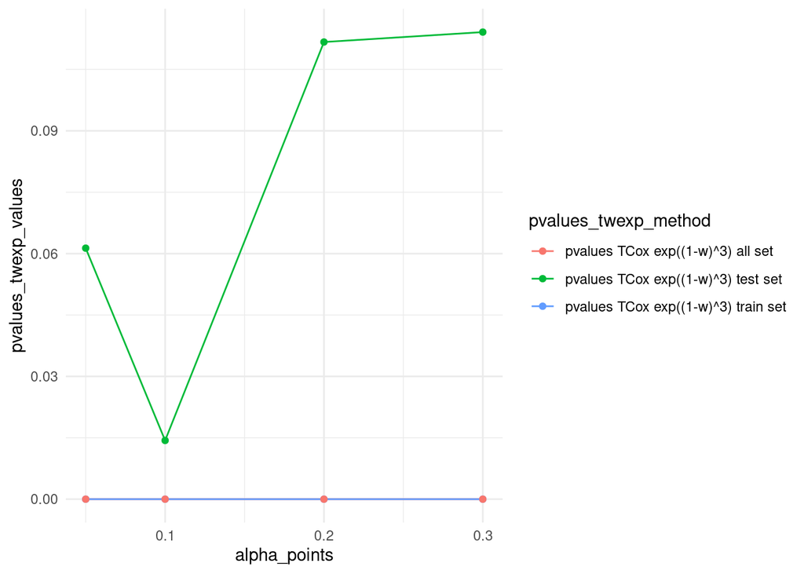

```r
alpha_points<-c(0.3, 0.2,0.1,0.05)

pvalues_twexp_values_train<-c(train_twexp03$pvalue,train_twexp02$pvalue,train_twexp01$pvalue,train_twexp05$pvalue)

pvalues_twexp_values_test<-c(test_twexp03$pvalue,test_twexp02$pvalue,test_twexp01$pvalue,test_twexp05$pvalue)

pvalues_twexp_values_all<-c(all_twexp03$pvalue,all_twexp02$pvalue,all_twexp01$pvalue,all_twexp05$pvalue)



pvalues_twexp_values<-c(train_twexp03$pvalue,train_twexp02$pvalue,train_twexp01$pvalue,train_twexp05$pvalue,test_twexp03$pvalue,test_twexp02$pvalue,test_twexp01$pvalue,test_twexp05$pvalue,all_twexp03$pvalue,all_twexp02$pvalue,all_twexp01$pvalue,all_twexp05$pvalue)



pvalues_twexp_method<-c(rep("pvalues TCox exp((1-w)^3) train set",4),rep("pvalues TCox exp((1-w)^3) test set",4),rep("pvalues TCox exp((1-w)^3) all set",4))




pvalues_twexp<-data.frame(alpha_points,pvalues_twexp_values,pvalues_twexp_method)
p_pvalues_twexp<-ggplot(data = pvalues_twexp, aes(x = alpha_points, y = pvalues_twexp_values,color= pvalues_twexp_method)) + geom_line()+geom_point()+theme_minimal()
p_pvalues_twexp+ ylim(0, max(pvalues_twexp_values))
```

### 3.2.5 1-normal weight^3

#### 3.2.5.1 0.3

```r
#glmnet
cv.fit_twele3 <- twiner_glmnet(xdata.train,ydata.train,0.3, tumornormal_weights2)


#genes
coefs.v_twele3 <- twiner_coefs(cv.fit_twele3)

fit.selected_twele3 <- twiner_genes(cv.fit_twele3)
length(fit.selected_twele3)
```

```
## [1] 21
```

```r
#train
train_twele03 <- train (coefs.v_twele3)
train_twele03$pvalue ## these values are the ones in Table 1
```

```
## [1] 3.783471e-07
```

```r
#test
test_twele03 <- test (coefs.v_twele3)
test_twele03$pvalue
```

```
## [1] 0.06125732
```

```r
#all
all_twele03 <- all (coefs.v_twele3)
```

#### 3.2.5.2 0.2

```r
#glmnet
cv.fit_twele2 <- twiner_glmnet(xdata.train,ydata.train,0.2, tumornormal_weights2)


#genes
coefs.v_twele2 <- twiner_coefs(cv.fit_twele2)

fit.selected_twele2 <- twiner_genes(cv.fit_twele2)
length(fit.selected_twele2)
```

```
## [1] 21
```

```r
#train
train_twele02 <- train (coefs.v_twele2)

#test
test_twele02 <- test (coefs.v_twele2)

#all
all_twele02 <- all (coefs.v_twele2)
```

#### 3.2.5.3 0.1

```r
#glmnet
cv.fit_twele1 <- twiner_glmnet(xdata.train,ydata.train,0.1, tumornormal_weights2)

#genes
coefs.v_twele1 <- twiner_coefs(cv.fit_twele1)

fit.selected_twele1 <- twiner_genes(cv.fit_twele1)
length(fit.selected_twele1)
```

```
## [1] 33
```

```r
#train
train_twele01 <- train (coefs.v_twele1)

#test
test_twele01 <- test (coefs.v_twele1)

#all
all_twele01 <- all (coefs.v_twele1)
```

#### 3.2.5.4 0.05

```r
#glmnet
cv.fit_twele05 <- twiner_glmnet(xdata.train,ydata.train,0.05, tumornormal_weights2)

#genes
coefs.v_twele05 <- twiner_coefs(cv.fit_twele05)

fit.selected_twele05 <- twiner_genes(cv.fit_twele05)
length(fit.selected_twele05)
```

```
## [1] 46
```

```r
#train
train_twele05 <- train (coefs.v_twele05)

#test
test_twele05 <- test (coefs.v_twele05)

#all
all_twele05 <- all (coefs.v_twele05)
```

#### 3.2.5.5 plot

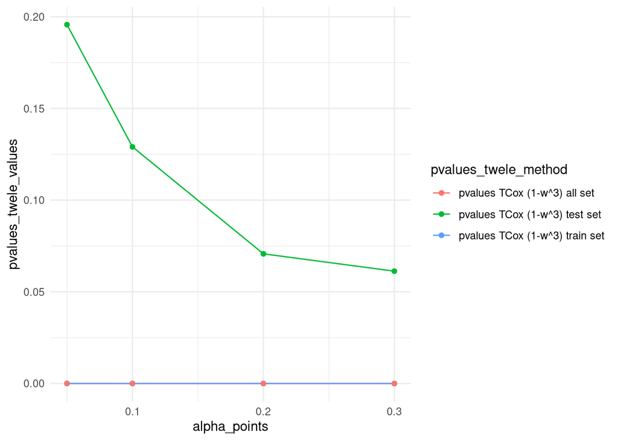

```r
alpha_points<-c(0.3, 0.2,0.1,0.05)

pvalues_twele_values_train<-c(train_twele03$pvalue,train_twele02$pvalue,train_twele01$pvalue,train_twele05$pvalue)

pvalues_twele_values_test<-c(test_twele03$pvalue,test_twele02$pvalue,test_twele01$pvalue,test_twele05$pvalue)

pvalues_twele_values_all<-c(all_twele03$pvalue,all_twele02$pvalue,all_twele01$pvalue,all_twele05$pvalue)



pvalues_twele_values<-c(train_twele03$pvalue,train_twele02$pvalue,train_twele01$pvalue,train_twele05$pvalue,test_twele03$pvalue,test_twele02$pvalue,test_twele01$pvalue,test_twele05$pvalue,all_twele03$pvalue,all_twele02$pvalue,all_twele01$pvalue,all_twele05$pvalue)



pvalues_twele_method<-c(rep("pvalues TCox (1-w^3) train set",4),rep("pvalues TCox (1-w^3) test set",4),rep("pvalues TCox (1-w^3) all set",4))




pvalues_twele<-data.frame(alpha_points,pvalues_twele_values,pvalues_twele_method)
p_pvalues_twele<-ggplot(data = pvalues_twele, aes(x = alpha_points, y = pvalues_twele_values,color= pvalues_twele_method)) + geom_line()+geom_point()+theme_minimal()
p_pvalues_twele+ ylim(0, max(pvalues_twele_values))
```

### 3.2.6 (1-normal weight)^3

#### 3.2.6.1 0.3

```r
#glmnet
cv.fit_tweleele3 <- twiner_glmnet(xdata.train,ydata.train,0.3, tumornormal_weights3)


#genes
coefs.v_tweleele3 <- twiner_coefs(cv.fit_tweleele3)

fit.selected_tweleele3 <- twiner_genes(cv.fit_tweleele3)
length(fit.selected_tweleele3)
```

```
## [1] 21
```

```r
#train
train_tweleele03 <- train (coefs.v_tweleele3)
train_tweleele03$pvalue ## these values are the ones in Table 1
```

```
## [1] 2.406974e-06
```

```r
#test
test_tweleele03 <- test (coefs.v_tweleele3)
test_tweleele03$pvalue
```

```
## [1] 0.534717
```

```r
#all
all_tweleele03 <- all (coefs.v_tweleele3)
```

#### 3.2.6.2 0.2

```r
#glmnet
cv.fit_tweleele2 <- twiner_glmnet(xdata.train,ydata.train,0.2, tumornormal_weights3)


#genes
coefs.v_tweleele2 <- twiner_coefs(cv.fit_tweleele2)

fit.selected_tweleele2 <- twiner_genes(cv.fit_tweleele2)
length(fit.selected_tweleele2)
```

```
## [1] 21
```

```r
#train
train_tweleele02 <- train (coefs.v_tweleele2)

#test
test_tweleele02 <- test (coefs.v_tweleele2)

#all
all_tweleele02 <- all (coefs.v_tweleele2)
```

#### 3.2.6.3 0.1

```r
#glmnet
cv.fit_tweleele1 <- twiner_glmnet(xdata.train,ydata.train,0.1, tumornormal_weights3)

#genes
coefs.v_tweleele1 <- twiner_coefs(cv.fit_tweleele1)

fit.selected_tweleele1 <- twiner_genes(cv.fit_tweleele1)
length(fit.selected_tweleele1)
```

```
## [1] 25
```

```r
#train
train_tweleele01 <- train (coefs.v_tweleele1)

#test
test_tweleele01 <- test (coefs.v_tweleele1)

#all
all_tweleele01 <- all (coefs.v_tweleele1)
```

#### 3.2.6.4 0.05

```r
#glmnet
cv.fit_tweleele05 <- twiner_glmnet(xdata.train,ydata.train,0.05, tumornormal_weights3)

#genes
coefs.v_tweleele05 <- twiner_coefs(cv.fit_tweleele05)

fit.selected_tweleele05 <- twiner_genes(cv.fit_tweleele05)
length(fit.selected_tweleele05)
```

```
## [1] 30
```

```r
#train
train_tweleele05 <- train (coefs.v_tweleele05)

#test
test_tweleele05 <- test (coefs.v_tweleele05)

#all
all_tweleele05 <- all (coefs.v_tweleele05)
```

#### 3.2.6.5 plot

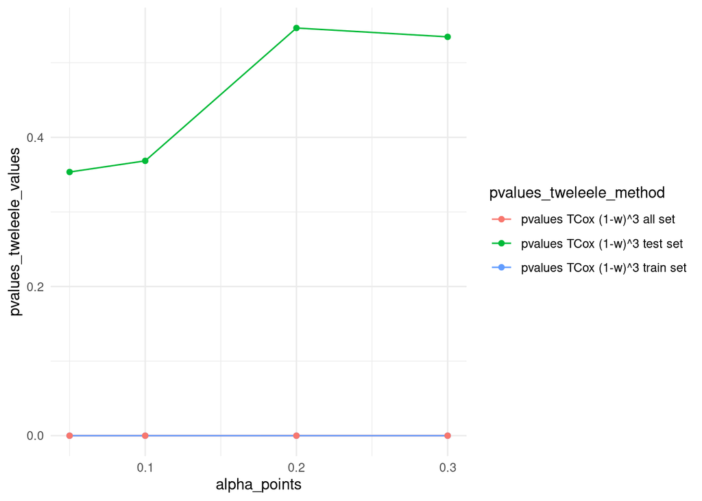

```r
alpha_points<-c(0.3, 0.2,0.1,0.05)

pvalues_tweleele_values_train<-c(train_tweleele03$pvalue,train_tweleele02$pvalue,train_tweleele01$pvalue,train_tweleele05$pvalue)

pvalues_tweleele_values_test<-c(test_tweleele03$pvalue,test_tweleele02$pvalue,test_tweleele01$pvalue,test_tweleele05$pvalue)

pvalues_tweleele_values_all<-c(all_tweleele03$pvalue,all_tweleele02$pvalue,all_tweleele01$pvalue,all_tweleele05$pvalue)



pvalues_tweleele_values<-c(train_tweleele03$pvalue,train_tweleele02$pvalue,train_tweleele01$pvalue,train_tweleele05$pvalue,test_tweleele03$pvalue,test_tweleele02$pvalue,test_tweleele01$pvalue,test_tweleele05$pvalue,all_tweleele03$pvalue,all_tweleele02$pvalue,all_tweleele01$pvalue,all_tweleele05$pvalue)



pvalues_tweleele_method<-c(rep("pvalues TCox (1-w)^3 train set",4),rep("pvalues TCox (1-w)^3 test set",4),rep("pvalues TCox (1-w)^3 all set",4))




pvalues_tweleele<-data.frame(alpha_points,pvalues_tweleele_values,pvalues_tweleele_method)
p_pvalues_tweleele<-ggplot(data = pvalues_tweleele, aes(x = alpha_points, y = pvalues_tweleele_values,color= pvalues_tweleele_method)) + geom_line()+geom_point()+theme_minimal()
p_pvalues_tweleele+ ylim(0, max(pvalues_tweleele_values))
```

### 3.2.7 final plot with all weights - Figure 2

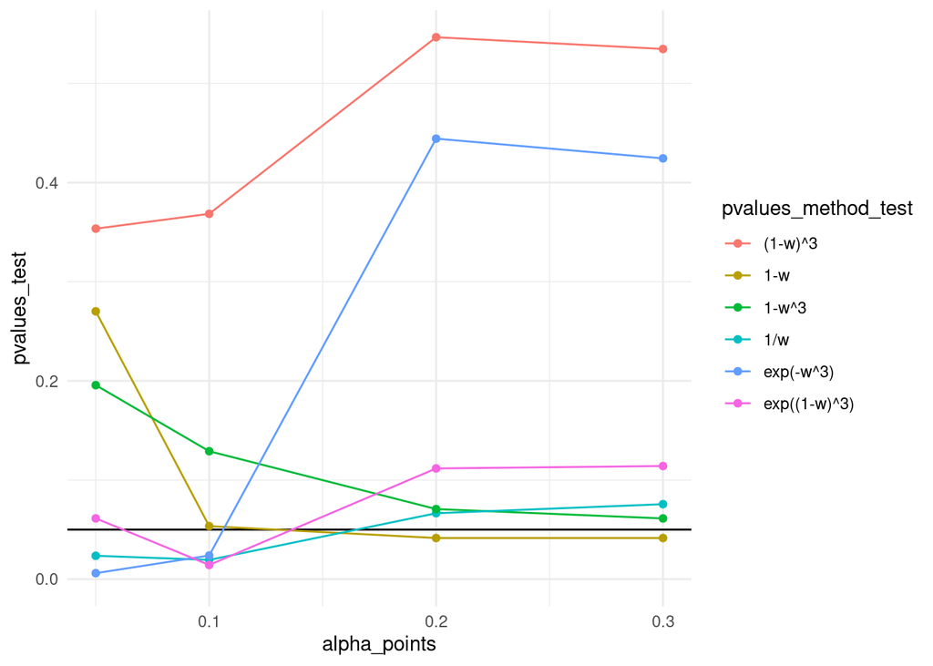

```r
alpha_points<-c(0.3,0.2,0.1,0.05)

#1-w
pvalues_tw1i_values_test<-c(test_tw1i03$pvalue,test_tw1i02$pvalue,test_tw1i01$pvalue,test_tw1i05$pvalue)
#1/w
pvalues_twii_values_test<-c(test_twii03$pvalue,test_twii02$pvalue,test_twii01$pvalue,test_twii05$pvalue)
#exp((1-w)^3)
pvalues_twexp_values_test<-c(test_twexp03$pvalue,test_twexp02$pvalue,test_twexp01$pvalue,test_twexp05$pvalue)
#exp(-w^3)
pvalues_twexp2_values_test<-c(test_twexp203$pvalue,test_twexp202$pvalue,test_twexp201$pvalue,test_twexp205$pvalue)
#1-w^3
pvalues_twele_values_test<-c(test_twele03$pvalue,test_twele02$pvalue,test_twele01$pvalue,test_twele05$pvalue)
#(1-w)^3
pvalues_tweleele_values_test<-c(test_tweleele03$pvalue,test_tweleele02$pvalue,test_tweleele01$pvalue,test_tweleele05$pvalue)



pvalues_test<-c(pvalues_tw1i_values_test,pvalues_twii_values_test,pvalues_twexp_values_test,pvalues_twexp2_values_test,pvalues_twele_values_test,pvalues_tweleele_values_test)

pvalues_method_test<-c( rep("1-w",4), rep("1/w",4), rep("exp((1-w)^3)",4), rep("exp(-w^3)",4),rep("1-w^3 ",4),rep("(1-w)^3",4))

pvalues_test_data<-data.frame(alpha_points,pvalues_test,pvalues_method_test)
p_pvalues_test<-ggplot(data = pvalues_test_data, aes(x = alpha_points, y = pvalues_test,color= pvalues_method_test)) + geom_hline(yintercept=0.05) + geom_line()+geom_point()+theme_minimal()
p_pvalues_test+ ylim(0, max(pvalues_test))
```

## 3.3 Demonstrative train and test survival curves - Figure 3

Train and Test curves obtained using 1/w weight vector and alpha = 0.1

```r
#train
train_twii01
```

```
## $pvalue
## [1] 2.664447e-09
##
## $plot
```

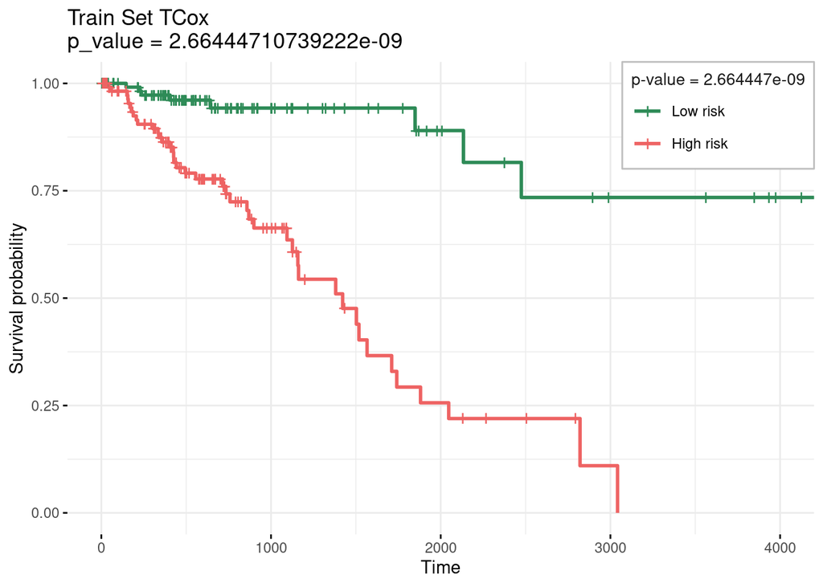

```
##
## $km
## Call: survfit(formula = survival::Surv(time, status) ~ group, data = prognostic.index.df)
##
##             n events median 0.95LCL 0.95UCL
## Low risk  125      8     NA      NA      NA
## High risk 124     42   1422    1126    1741
```

```r
#test
test_twii01
```

```
## $pvalue
## [1] 0.01944886
##
## $plot
```

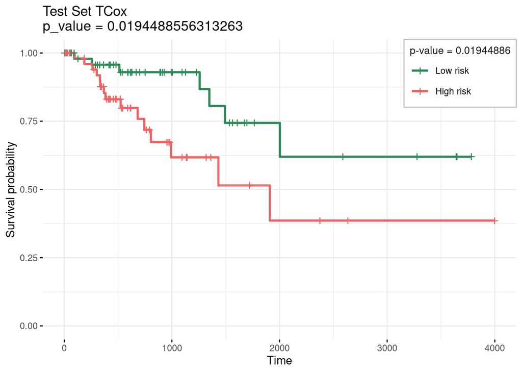

```
##
## $km
## Call: survfit(formula = survival::Surv(time, status) ~ group, data = prognostic.index.df)
##
##            n events median 0.95LCL 0.95UCL
## Low risk  54      7     NA    2003      NA
## High risk 54     15   1910     992      NA
```

# 4 Compare all models

## 4.1 EN

### 4.1.1 alpha=0.3

```r
cv.fit_elastic_net3<-cv.glmnet(as.matrix(xdata.train),as.matrix(ydata.train),
                               family = 'cox',foldid = my_foldid,
                               alpha = 0.3,
                               nlambda = 100,
                               #lambda.min.ratio = 10^(-3),
                               nfolds= params$nfolds)

coefs.v_elastic3 <- coef(cv.fit_elastic_net3, s = 'lambda.min')[,1] %>% { .[. != 0]}

fit.selected_elastic3 <- which(cv.fit_elastic_net3$glmnet.fit$beta[,which(cv.fit_elastic_net3$cvm == min(cv.fit_elastic_net3$cvm))] != 0)

length(fit.selected_elastic3)
```

```
## [1] 18
```

```r
train_en03<-separate2GroupsCox(as.vector(coefs.v_elastic3),
                               xdata.train[, names(coefs.v_elastic3)],
                               ydata.train,
                               plot.title = 'Train Set Elastic Net, alpha=0.3', legend.outside = FALSE)
train_en03$pvalue
```

```
## [1] 8.387034e-07
```

```r
test_en03<-separate2GroupsCox(as.vector(coefs.v_elastic3),
                              xdata.test[, names(coefs.v_elastic3)],
                              ydata.test,
                              plot.title = 'Test Set Elastic Net, alpha=0.3', legend.outside = FALSE)
test_en03$pvalue
```

```
## [1] 0.00882275
```

```r
all_en03<-separate2GroupsCox(as.vector(coefs.v_elastic3),
                             xdata[, names(coefs.v_elastic3)],
                             ydata %>% mutate(time = time / 365 * 12),
                             plot.title = 'All data Elastic Net, alpha=0.3', legend.outside = FALSE,
                             break.x.by = 12)
```

### 4.1.2 alpha=0.2

```r
cv.fit_elastic_net2<-cv.glmnet(as.matrix(xdata.train),as.matrix(ydata.train),
                          family = 'cox',foldid = my_foldid,
                          alpha = 0.2,
                        nlambda = 100,
               #lambda.min.ratio = 10^(-2),
                          nfolds= params$nfolds)

coefs.v_elastic2 <- coef(cv.fit_elastic_net2, s = 'lambda.min')[,1] %>% { .[. != 0]}

fit.selected_elastic2 <- which(cv.fit_elastic_net2$glmnet.fit$beta[,which(cv.fit_elastic_net2$cvm == min(cv.fit_elastic_net2$cvm))] != 0)

length(fit.selected_elastic2)
```

```
## [1] 47
```

```r
names(fit.selected_elastic2)
```

```
##  [1] "AASS"         "AFF3"         "BACH2"        "C1orf185"     "C7orf13"
##  [6] "CLDN9"        "CLEC17A"      "CLEC18C"      "CYP7A1"       "DCAF10"
## [11] "EEPD1"        "ELFN1"        "ENO3"         "FAM129C"      "FAM138B"
## [16] "FAM159A"      "FATE1"        "FCRL1"        "GRAPL"        "ISL2"
## [21] "KCNMB3"       "LBX2"         "LOC100130238" "LOC220930"    "LOC646498"
## [26] "LOC732275"    "MBL1P"        "MEIG1"        "MYF6"         "MYH8"
## [31] "NGLY1"        "NKAIN4"       "NKX1-2"       "PBX4"         "PCDHB12"
## [36] "PGAM2"        "PI4K2B"       "PRCD"         "PTPN6"        "RFPL4B"
## [41] "RPP14"        "SIX2"         "TCL1A"        "TMEM86B"      "UNC45B"
## [46] "ZDHHC19"      "ZNF883"
```

```r
train_en02<-separate2GroupsCox(as.vector(coefs.v_elastic2),
                   xdata.train[, names(coefs.v_elastic2)],
                   ydata.train,
                   plot.title = 'Train Set Elastic Net, alpha=0.2', legend.outside = FALSE)
train_en02$pvalue
```

```
## [1] 2.474278e-08
```

```r
test_en02<-separate2GroupsCox(as.vector(coefs.v_elastic2),
                   xdata.test[, names(coefs.v_elastic2)],
                   ydata.test,
                   plot.title = 'Test Set Elastic Net, alpha=0.2', legend.outside = FALSE)
test_en02$pvalue
```

```
## [1] 0.07168201
```

```r
all_en02<-separate2GroupsCox(as.vector(coefs.v_elastic2),
                   xdata[, names(coefs.v_elastic2)],
                   ydata %>% mutate(time = time / 365 * 12),
                   plot.title = 'All data Elastic Net, alpha=0.2', legend.outside = FALSE,
                   break.x.by = 12)
```

### 4.1.3 alpha=0.1

```r
cv.fit_elastic_net1<-cv.glmnet(as.matrix(xdata.train),as.matrix(ydata.train),
                          family = 'cox',foldid = my_foldid,
                          alpha = 0.1,
                        nlambda = 100,
               #lambda.min.ratio = 10^(-2),
                          nfolds= params$nfolds)


coefs.v_elastic1 <- coef(cv.fit_elastic_net1, s = 'lambda.min')[,1] %>% { .[. != 0]}

fit.selected_elastic1 <- which(cv.fit_elastic_net1$glmnet.fit$beta[,which(cv.fit_elastic_net1$cvm == min(cv.fit_elastic_net1$cvm))] != 0)

length(fit.selected_elastic1)
```

```
## [1] 88
```

```r
names(fit.selected_elastic1)
```

```
##  [1] "AASS"         "AFF3"         "BACH2"        "BLK"          "C10orf114"
##  [6] "C14orf72"     "C1orf185"     "C2CD4C"       "C7orf13"      "C9orf82"
## [11] "CABP5"        "CAPRIN2"      "CCDC126"      "CD19"         "CDH18"
## [16] "CLDN9"        "CLEC17A"      "CLEC18C"      "CLVS2"        "CST2"
## [21] "CUZD1"        "CYP7A1"       "DCAF10"       "DNAI2"        "EEPD1"
## [26] "EGFL7"        "ELFN1"        "EML6"         "ENO3"         "FAM129C"
## [31] "FAM138B"      "FAM159A"      "FAM81B"       "FATE1"        "FCER2"
## [36] "FCRL1"        "GABRD"        "GJA3"         "GRAPL"        "GUCA1B"
## [41] "HOTAIR"       "HPCAL1"       "ISL2"         "KCNMB3"       "LBX2"
## [46] "LOC100130238" "LOC220930"    "LOC283663"    "LOC646498"    "LOC732275"
## [51] "LRP2BP"       "MBL1P"        "MEF2B"        "MEIG1"        "MYF6"
## [56] "MYH8"         "NCF1C"        "NEK4"         "NELF"         "NGLY1"
## [61] "NKAIN4"       "NKX1-2"       "PAX5"         "PBX4"         "PCDHB12"
## [66] "PGAM2"        "PI4K2B"       "PRCD"         "PRR4"         "PTPN6"
## [71] "PYROXD2"      "RASA4P"       "RFPL4B"       "RPP14"        "SHOX2"
## [76] "SIX2"         "SLC25A18"     "TAS2R20"      "TCF15"        "TCL1A"
## [81] "TERT"         "TMEM86B"      "TMEM90B"      "TUBA8"        "UNC45B"
## [86] "ZDHHC19"      "ZNF607"       "ZNF883"
```

```r
train_en01<-separate2GroupsCox(as.vector(coefs.v_elastic1),
                   xdata.train[, names(coefs.v_elastic1)],
                   ydata.train,
                   plot.title = 'Train Set Elastic Net, alpha=0.1', legend.outside = FALSE)
train_en01$pvalue
```

```
## [1] 5.28787e-09
```

```r
test_en01<-separate2GroupsCox(as.vector(coefs.v_elastic1),
                   xdata.test[, names(coefs.v_elastic1)],
                   ydata.test,
                   plot.title = 'Test Set Elastic Net, alpha=0.1', legend.outside = FALSE)
test_en01$pvalue
```

```
## [1] 0.04921873
```

```r
all_en01<-separate2GroupsCox(as.vector(coefs.v_elastic1),
                   xdata[, names(coefs.v_elastic1)],
                   ydata %>% mutate(time = time / 365 * 12),
                   plot.title = 'All data Elastic Net, alpha=0.1', legend.outside = FALSE,
                   break.x.by = 12)
```

### 4.1.4 alpha=0.05

```r
cv.fit_elastic_net05<-cv.glmnet(as.matrix(xdata.train),as.matrix(ydata.train),
                          family = 'cox',foldid = my_foldid,
                          alpha = 0.05,
                        nlambda = 100,
               #lambda.min.ratio = 10^(-2),
                          nfolds= params$nfolds)

coefs.v_elastic05 <- coef(cv.fit_elastic_net05, s = 'lambda.min')[,1] %>% { .[. != 0]}

fit.selected_elastic05 <- which(cv.fit_elastic_net05$glmnet.fit$beta[,which(cv.fit_elastic_net05$cvm == min(cv.fit_elastic_net05$cvm))] != 0)

length(fit.selected_elastic05)
```

```
## [1] 133
```

```r
train_en05<-separate2GroupsCox(as.vector(coefs.v_elastic05),
                   xdata.train[, names(coefs.v_elastic05)],
                   ydata.train,
                   plot.title = 'Train Set Elastic Net, alpha=0.05', legend.outside = FALSE)

test_en05<-separate2GroupsCox(as.vector(coefs.v_elastic05),
                   xdata.test[, names(coefs.v_elastic05)],
                   ydata.test,
                   plot.title = 'Test Set Elastic Net, alpha=0.05', legend.outside = FALSE)

all_en05<-separate2GroupsCox(as.vector(coefs.v_elastic05),
                   xdata[, names(coefs.v_elastic05)],
                   ydata %>% mutate(time = time / 365 * 12),
                   plot.title = 'All data Elastic Net, alpha=0.05', legend.outside = FALSE,
                   break.x.by = 12)
```

```r
cv.fit_elastic_net04<-cv.glmnet(as.matrix(xdata.train),as.matrix(ydata.train),
                          family = 'cox',foldid = my_foldid,
                          alpha = 0.04,
                        nlambda = 100,
               #lambda.min.ratio = 10^(-2),
                          nfolds= params$nfolds)

coefs.v_elastic04 <- coef(cv.fit_elastic_net04, s = 'lambda.min')[,1] %>% { .[. != 0]}

fit.selected_elastic04 <- which(cv.fit_elastic_net04$glmnet.fit$beta[,which(cv.fit_elastic_net04$cvm == min(cv.fit_elastic_net04$cvm))] != 0)

length(fit.selected_elastic04)
```

```
## [1] 141
```

```r
train_en04<-separate2GroupsCox(as.vector(coefs.v_elastic04),
                   xdata.train[, names(coefs.v_elastic04)],
                   ydata.train,
                   plot.title = 'Train Set Elastic Net, alpha=0.04', legend.outside = FALSE)

test_en04<-separate2GroupsCox(as.vector(coefs.v_elastic04),
                   xdata.test[, names(coefs.v_elastic04)],
                   ydata.test,
                   plot.title = 'Test Set Elastic Net, alpha=0.04', legend.outside = FALSE)

all_en04<-separate2GroupsCox(as.vector(coefs.v_elastic04),
                   xdata[, names(coefs.v_elastic04)],
                   ydata %>% mutate(time = time / 365 * 12),
                   plot.title = 'All data Elastic Net, alpha=0.04', legend.outside = FALSE,
                   break.x.by = 12)
```

### 4.1.5 Pvalues KM

```r
alpha_points<-c(0.3,0.2,0.1,0.05)

pvalues_en_train<-c(train_en03$pvalue,train_en02$pvalue,train_en01$pvalue,train_en05$pvalue)

pvalues_en_test<-c(test_en03$pvalue,test_en02$pvalue,test_en01$pvalue,test_en05$pvalue)

pvalues_en_all<-c(all_en03$pvalue,all_en02$pvalue,all_en01$pvalue,all_en05$pvalue)
```

```r
pvalues_en_values<-c(train_en03$pvalue,train_en02$pvalue,train_en01$pvalue,train_en05$pvalue,
test_en03$pvalue,test_en02$pvalue,test_en01$pvalue,test_en05$pvalue,
all_en03$pvalue,all_en02$pvalue,all_en01$pvalue,all_en05$pvalue)

pvalues_en_method<-c(rep("pvalues en train set",4),rep("pvalues en test set",4),rep("pvalues en all set",4))
```

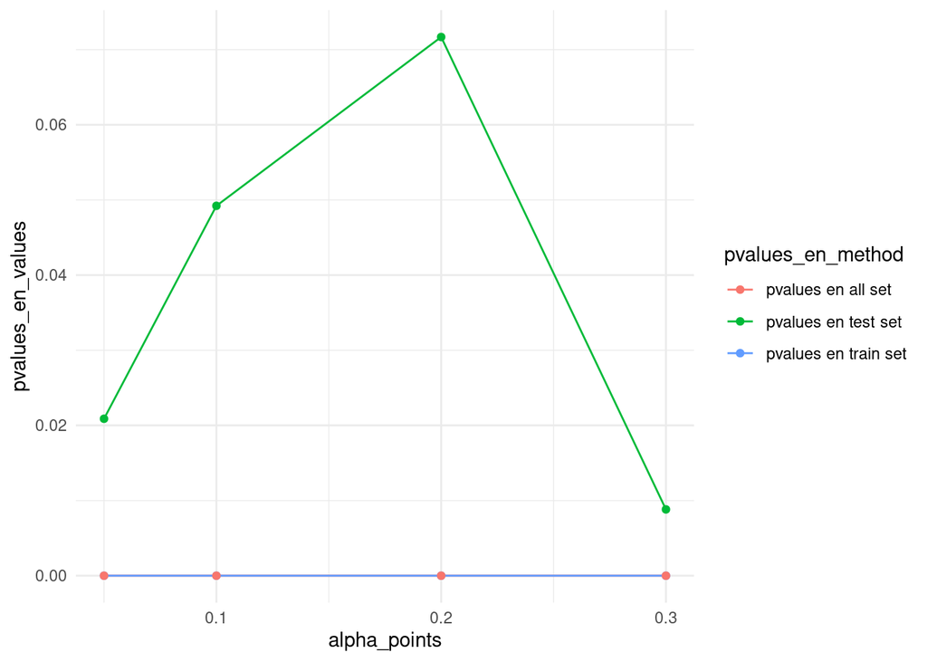

## 4.2 Hub

### 4.2.1 alpha=0.3

```r
cv.fit_hub3<-cv.glmHub(as.matrix(xdata.train),as.matrix(ydata.train),
                       family = 'cox',foldid = my_foldid, network = "correlation",
                       alpha = 0.3,
                       nlambda = 100,
                       #lambda.min.ratio = 10^(-3),
                       nfolds= params$nfolds, network.options =  networkOptions(cutoff = 0.005,                                                                   min.degree = 0.6))
coefs.v_hub3 <- coef(cv.fit_hub3, s = 'lambda.min')[,1] %>% { .[. != 0]}

fit.selected_hub3 <- which(cv.fit_hub3$glmnet.fit$beta[,which(cv.fit_hub3$cvm == min(cv.fit_hub3$cvm))] != 0)

length(fit.selected_hub3)
```

```
## [1] 26
```

```r
train_hub03<-separate2GroupsCox(as.vector(coefs.v_hub3),
                                xdata.train[, names(coefs.v_hub3)],
                                ydata.train,
                                plot.title = 'Train Set hub Net, alpha=0.3', legend.outside = FALSE)
train_hub03$pvalue
```

```
## [1] 1.788036e-08
```

```r
test_hub03<-separate2GroupsCox(as.vector(coefs.v_hub3),
                               xdata.test[, names(coefs.v_hub3)],
                               ydata.test,
                               plot.title = 'Test Set hub Net, alpha=0.3', legend.outside = FALSE)
test_hub03$pvalue
```

```
## [1] 0.01382812
```

```r
all_hub03<-separate2GroupsCox(as.vector(coefs.v_hub3),
                              xdata[, names(coefs.v_hub3)],
                              ydata %>% mutate(time = time / 365 * 12),
                              plot.title = 'All data hub Net, alpha=0.3', legend.outside = FALSE,
                              break.x.by = 12)
```

### 4.2.2 alpha=0.2

```r
cv.fit_hub2<-cv.glmHub(as.matrix(xdata.train),as.matrix(ydata.train),
                          family = 'cox',foldid = my_foldid, network = "correlation",
                          alpha = 0.2,
                        nlambda = 100,
               #lambda.min.ratio = 10^(-2),
                          nfolds= params$nfolds, network.options =  networkOptions(cutoff = 0.005,                                                                   min.degree = 0.6))
coefs.v_hub2 <- coef(cv.fit_hub2, s = 'lambda.min')[,1] %>% { .[. != 0]}

fit.selected_hub2 <- which(cv.fit_hub2$glmnet.fit$beta[,which(cv.fit_hub2$cvm == min(cv.fit_hub2$cvm))] != 0)

length(fit.selected_hub2)
```

```
## [1] 47
```

```r
names(fit.selected_hub2)
```

```
##  [1] "AASS"      "AFF3"      "BACH2"     "BLK"       "C14orf72"  "C7orf13"
##  [7] "CLDN9"     "CLEC17A"   "DCAF10"    "EEPD1"     "EGFL7"     "ELFN1"
## [13] "ENO3"      "FAM129C"   "FAM138B"   "FAM159A"   "FCRL1"     "GRAPL"
## [19] "KCNMB3"    "LBX2"      "LOC220930" "LOC646498" "LOC732275" "MBL1P"
## [25] "MEIG1"     "MYF6"      "MYH8"      "NCF1C"     "NGLY1"     "NKAIN4"
## [31] "NKX1-2"    "PAX5"      "PBX4"      "PCDHB12"   "PGAM2"     "PI4K2B"
## [37] "PRCD"      "PTPN6"     "RPP14"     "SHOX2"     "SIX2"      "TCL1A"
## [43] "TMEM86B"   "TMEM90B"   "UNC45B"    "ZDHHC19"   "ZNF883"
```

```r
train_hub02<-separate2GroupsCox(as.vector(coefs.v_hub2),
                   xdata.train[, names(coefs.v_hub2)],
                   ydata.train,
                   plot.title = 'Train Set hub Net, alpha=0.2', legend.outside = FALSE)
train_hub02$pvalue
```

```
## [1] 1.18224e-08
```

```r
test_hub02<-separate2GroupsCox(as.vector(coefs.v_hub2),
                   xdata.test[, names(coefs.v_hub2)],
                   ydata.test,
                   plot.title = 'Test Set hub Net, alpha=0.2', legend.outside = FALSE)
test_hub02$pvalue
```

```
## [1] 0.01288524
```

```r
all_hub02<-separate2GroupsCox(as.vector(coefs.v_hub2),
                   xdata[, names(coefs.v_hub2)],
                   ydata %>% mutate(time = time / 365 * 12),
                   plot.title = 'All data hub Net, alpha=0.2', legend.outside = FALSE,
                   break.x.by = 12)
```

### 4.2.3 alpha=0.1

```r
cv.fit_hub1<-cv.glmHub(as.matrix(xdata.train),as.matrix(ydata.train),
                          family = 'cox',foldid = my_foldid, network = "correlation",
                          alpha = 0.1,
                        nlambda = 100,
               #lambda.min.ratio = 10^(-2),
                          nfolds= params$nfolds, network.options =  networkOptions(cutoff = 0.005,                                                                   min.degree = 0.6))


coefs.v_hub1 <- coef(cv.fit_hub1, s = 'lambda.min')[,1] %>% { .[. != 0]}

fit.selected_hub1 <- which(cv.fit_hub1$glmnet.fit$beta[,which(cv.fit_hub1$cvm == min(cv.fit_hub1$cvm))] != 0)

length(fit.selected_hub1)
```

```
## [1] 90
```

```r
names(fit.selected_hub1)
```

```
##  [1] "AASS"         "AFF3"         "BACH2"        "BEND4"        "BLK"
##  [6] "C10orf114"    "C14orf72"     "C1orf185"     "C2CD4C"       "C7orf13"
## [11] "C9orf82"      "CAPRIN2"      "CCDC126"      "CD19"         "CDH18"
## [16] "CLDN9"        "CLEC17A"      "CLEC18C"      "CLVS2"        "CST2"
## [21] "CUZD1"        "CYGB"         "CYP27C1"      "CYP7A1"       "DCAF10"
## [26] "EEPD1"        "EGFL7"        "ELFN1"        "EML6"         "ENO3"
## [31] "FAM129C"      "FAM138B"      "FAM159A"      "FAM24B"       "FATE1"
## [36] "FCRL1"        "GABRD"        "GRAPL"        "HPCAL1"       "IFT74"
## [41] "ISL2"         "KCNMB3"       "LBX2"         "LIPT2"        "LOC100130238"
## [46] "LOC220930"    "LOC285074"    "LOC646498"    "LOC732275"    "LRP2BP"
## [51] "MBL1P"        "MEF2B"        "MEIG1"        "MYF6"         "MYH8"
## [56] "NCF1C"        "NEK4"         "NGLY1"        "NKAIN4"       "NKX1-2"
## [61] "PAX5"         "PBX4"         "PCDHB12"      "PGAM2"        "PI4K2B"
## [66] "PRCD"         "PTPN6"        "PYROXD2"      "RASA4P"       "RASGRP2"
## [71] "RFPL4B"       "RFT1"         "RPP14"        "SHOX2"        "SIX2"
## [76] "SLC25A18"     "SLFN11"       "TAS2R20"      "TCF15"        "TCL1A"
## [81] "TERT"         "TMEM86B"      "TMEM90B"      "TUBA8"        "UNC13B"
## [86] "UNC45B"       "WBSCR27"      "ZDHHC19"      "ZNF607"       "ZNF883"
```

```r
train_hub01<-separate2GroupsCox(as.vector(coefs.v_hub1),
                   xdata.train[, names(coefs.v_hub1)],
                   ydata.train,
                   plot.title = 'Train Set hub Net, alpha=0.1', legend.outside = FALSE)
train_hub01$pvalue
```

```
## [1] 2.741041e-09
```

```r
test_hub01<-separate2GroupsCox(as.vector(coefs.v_hub1),
                   xdata.test[, names(coefs.v_hub1)],
                   ydata.test,
                   plot.title = 'Test Set hub Net, alpha=0.1', legend.outside = FALSE)
test_hub01$pvalue
```

```
## [1] 0.04180592
```

```r
all_hub01<-separate2GroupsCox(as.vector(coefs.v_hub1),
                   xdata[, names(coefs.v_hub1)],
                   ydata %>% mutate(time = time / 365 * 12),
                   plot.title = 'All data hub Net, alpha=0.1', legend.outside = FALSE,
                   break.x.by = 12)
```

### 4.2.4 alpha=0.05

```r
cv.fit_hub05<-cv.glmHub(as.matrix(xdata.train),as.matrix(ydata.train),
                          family = 'cox',foldid = my_foldid, network = "correlation",
                          alpha = 0.05,
                        nlambda = 100,
               #lambda.min.ratio = 10^(-2),
                          nfolds= params$nfolds, network.options =  networkOptions(cutoff = 0.005,                                                                   min.degree = 0.6))

coefs.v_hub05 <- coef(cv.fit_hub05, s = 'lambda.min')[,1] %>% { .[. != 0]}

fit.selected_hub05 <- which(cv.fit_hub05$glmnet.fit$beta[,which(cv.fit_hub05$cvm == min(cv.fit_hub05$cvm))] != 0)

length(fit.selected_hub05)
```

```
## [1] 163
```

```r
train_hub05<-separate2GroupsCox(as.vector(coefs.v_hub05),
                   xdata.train[, names(coefs.v_hub05)],
                   ydata.train,
                   plot.title = 'Train Set hub Net, alpha=0.05', legend.outside = FALSE)

test_hub05<-separate2GroupsCox(as.vector(coefs.v_hub05),
                   xdata.test[, names(coefs.v_hub05)],
                   ydata.test,
                   plot.title = 'Test Set hub Net, alpha=0.05', legend.outside = FALSE)

all_hub05<-separate2GroupsCox(as.vector(coefs.v_hub05),
                   xdata[, names(coefs.v_hub05)],
                   ydata %>% mutate(time = time / 365 * 12),
                   plot.title = 'All data hub Net, alpha=0.05', legend.outside = FALSE,
                   break.x.by = 12)
```

### 4.2.5 Pvalues KM

```r
alpha_points<-c(0.3, 0.2,0.1,0.05)

pvalues_hub_train<-c(train_hub03$pvalue,train_hub02$pvalue,train_hub01$pvalue,train_hub05$pvalue)

pvalues_hub_test<-c(test_hub03$pvalue,test_hub02$pvalue,test_hub01$pvalue,test_hub05$pvalue)

pvalues_hub_all<-c(all_hub03$pvalue,all_hub02$pvalue,all_hub01$pvalue,all_hub05$pvalue)
```

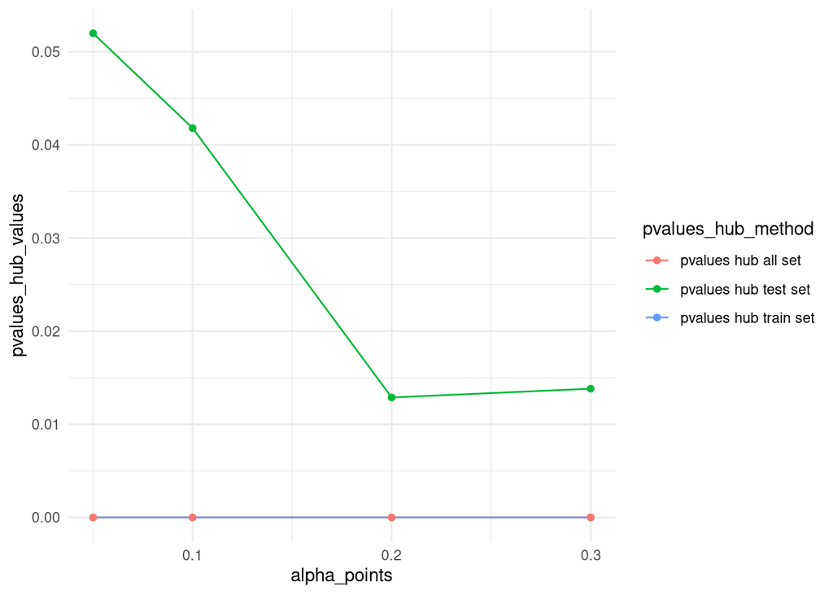

```r
pvalues_hub_values<-c(train_hub03$pvalue,train_hub02$pvalue,train_hub01$pvalue,train_hub05$pvalue,
                              test_hub03$pvalue,test_hub02$pvalue,test_hub01$pvalue,test_hub05$pvalue,
                              all_hub03$pvalue,all_hub02$pvalue,all_hub01$pvalue,all_hub05$pvalue)

pvalues_hub_method<-c(rep("pvalues hub train set",4),rep("pvalues hub test set",4),rep("pvalues hub all set",4))

pvalues_hub<-data.frame(alpha_points,pvalues_hub_values,pvalues_hub_method)
p_pvalues_hub<-ggplot(data = pvalues_hub, aes(x = alpha_points, y = pvalues_hub_values,color= pvalues_hub_method)) + geom_line()+geom_point()+theme_minimal()
p_pvalues_hub+ ylim(0, max(pvalues_hub_values))
```

## 4.3 Orphan

### 4.3.1 alpha=0.3

```r
cv.fit_orphan3<-cv.glmOrphan(as.matrix(xdata.train),as.matrix(ydata.train),
                             family = 'cox',foldid = my_foldid, network = "correlation",
                             alpha = 0.3,
                             nlambda = 100,
                             #lambda.min.ratio = 10^(-3),
                             nfolds= params$nfolds, network.options =  networkOptions(cutoff = 0.001,                                                                   min.degree = 0.6))

coefs.v_orphan3 <- coef(cv.fit_orphan3, s = 'lambda.min')[,1] %>% { .[. != 0]}

fit.selected_orphan3 <- which(cv.fit_orphan3$glmnet.fit$beta[,which(cv.fit_orphan3$cvm == min(cv.fit_orphan3$cvm))] != 0)

length(fit.selected_orphan3)
```

```
## [1] 8
```

```r
train_orphan03<-separate2GroupsCox(as.vector(coefs.v_orphan3),
                                   xdata.train[, names(coefs.v_orphan3)],
                                   ydata.train,
                                   plot.title = 'Train Set orphan Net, alpha=0.3', legend.outside = FALSE)
train_orphan03$pvalue
```

```
## [1] 2.489645e-05
```

```r
test_orphan03<-separate2GroupsCox(as.vector(coefs.v_orphan3),
                                  xdata.test[, names(coefs.v_orphan3)],
                                  ydata.test,
                                  plot.title = 'Test Set orphan Net, alpha=0.3', legend.outside = FALSE)
test_orphan03$pvalue
```

```
## [1] 0.1518845
```

```r
all_orphan03<-separate2GroupsCox(as.vector(coefs.v_orphan3),
                                 xdata[, names(coefs.v_orphan3)],
                                 ydata %>% mutate(time = time / 365 * 12),
                                 plot.title = 'All data orphan Net, alpha=0.3', legend.outside = FALSE,
                                 break.x.by = 12)
```

### 4.3.2 alpha=0.2

```r
cv.fit_orphan2<-cv.glmOrphan(as.matrix(xdata.train),as.matrix(ydata.train),
                               family = 'cox',foldid = my_foldid, network = "correlation",
                               alpha = 0.2,
                               nlambda = 100,
                               #lambda.min.ratio = 10^(-2),
                               nfolds= params$nfolds, network.options =  networkOptions(cutoff = 0.001,                                                                   min.degree = 0.6))

coefs.v_orphan2 <- coef(cv.fit_orphan2, s = 'lambda.min')[,1] %>% { .[. != 0]}

fit.selected_orphan2 <- which(cv.fit_orphan2$glmnet.fit$beta[,which(cv.fit_orphan2$cvm == min(cv.fit_orphan2$cvm))] != 0)

length(fit.selected_orphan2)
```

```
## [1] 44
```

```r
names(fit.selected_orphan2)
```

```
##  [1] "AFF3"         "BACH2"        "C7orf13"      "CLDN9"        "CLEC17A"
##  [6] "CLEC18C"      "CYP7A1"       "DCAF10"       "EEPD1"        "ELFN1"
## [11] "ENO3"         "FAM129C"      "FAM138B"      "FAM159A"      "FATE1"
## [16] "FCRL1"        "GRAPL"        "ISL2"         "KCNMB3"       "LBX2"
## [21] "LOC100130238" "LOC220930"    "LOC646498"    "LOC732275"    "MBL1P"
## [26] "MEIG1"        "MYF6"         "MYH8"         "NKAIN4"       "NKX1-2"
## [31] "PBX4"         "PCDHB12"      "PGAM2"        "PI4K2B"       "PRCD"
## [36] "PTPN6"        "RFPL4B"       "RPP14"        "SIX2"         "TCL1A"
## [41] "TMEM86B"      "UNC45B"       "ZDHHC19"      "ZNF883"
```

```r
train_orphan02<-separate2GroupsCox(as.vector(coefs.v_orphan2),
                               xdata.train[, names(coefs.v_orphan2)],
                               ydata.train,
                               plot.title = 'Train Set orphan Net, alpha=0.2', legend.outside = FALSE)
train_orphan02$pvalue
```

```
## [1] 1.204941e-07
```

```r
test_orphan02<-separate2GroupsCox(as.vector(coefs.v_orphan2),
                              xdata.test[, names(coefs.v_orphan2)],
                              ydata.test,
                              plot.title = 'Test Set orphan Net, alpha=0.2', legend.outside = FALSE)
test_orphan02$pvalue
```

```
## [1] 0.03266713
```

```r
all_orphan02<-separate2GroupsCox(as.vector(coefs.v_orphan2),
                             xdata[, names(coefs.v_orphan2)],
                             ydata %>% mutate(time = time / 365 * 12),
                             plot.title = 'All data orphan Net, alpha=0.2', legend.outside = FALSE,
                             break.x.by = 12)
```

### 4.3.3 alpha=0.1

```r
cv.fit_orphan1 <-cv.glmOrphan(as.matrix(xdata.train),as.matrix(ydata.train),
                               family = 'cox',foldid = my_foldid, network = "correlation",
                               alpha = 0.1,
                               nlambda = 100,
                               #lambda.min.ratio = 10^(-2),
                               nfolds= params$nfolds, network.options =  networkOptions(cutoff = 0.001,                                                                   min.degree = 0.6))

coefs.v_orphan1 <- coef(cv.fit_orphan1, s = 'lambda.min')[,1] %>% { .[. != 0]}

fit.selected_orphan1 <- which(cv.fit_orphan1$glmnet.fit$beta[,which(cv.fit_orphan1$cvm == min(cv.fit_orphan1$cvm))] != 0)

length(fit.selected_orphan1)
```

```
## [1] 67
```

```r
names(fit.selected_orphan1)
```

```
##  [1] "AASS"         "AFF3"         "BACH2"        "BLK"          "C1orf185"
##  [6] "C7orf13"      "CABP5"        "CAPRIN2"      "CCDC126"      "CD19"
## [11] "CDH18"        "CLDN9"        "CLEC17A"      "CLEC18C"      "CLVS2"
## [16] "CYP7A1"       "DCAF10"       "DPPA2"        "EEPD1"        "ELFN1"
## [21] "EML6"         "ENO3"         "FAM129C"      "FAM138B"      "FAM159A"
## [26] "FAM81B"       "FATE1"        "FCER2"        "FCRL1"        "GABRD"
## [31] "GRAPL"        "HPCAL1"       "ISL2"         "KCNMB3"       "LBX2"
## [36] "LOC100130238" "LOC220930"    "LOC646498"    "LOC732275"    "LRP2BP"
## [41] "MBL1P"        "MEIG1"        "MYF6"         "MYH8"         "NGLY1"
## [46] "NKAIN4"       "NKX1-2"       "PAX5"         "PBX4"         "PCDHB12"
## [51] "PGAM2"        "PI4K2B"       "PRCD"         "PRR4"         "PTPN6"
## [56] "RASA4P"       "RFPL4B"       "RPP14"        "SIX2"         "SLC25A18"
## [61] "TCF15"        "TCL1A"        "TMEM86B"      "TUBA8"        "UNC45B"
## [66] "ZDHHC19"      "ZNF883"
```

```r
train_orphan01<-separate2GroupsCox(as.vector(coefs.v_orphan1),
                               xdata.train[, names(coefs.v_orphan1)],
                               ydata.train,
                               plot.title = 'Train Set orphan Net, alpha=0.1', legend.outside = FALSE)
train_orphan01$pvalue
```

```
## [1] 6.802484e-09
```

```r
test_orphan01<-separate2GroupsCox(as.vector(coefs.v_orphan1),
                              xdata.test[, names(coefs.v_orphan1)],
                              ydata.test,
                              plot.title = 'Test Set orphan Net, alpha=0.1', legend.outside = FALSE)
test_orphan01$pvalue
```

```
## [1] 0.06322569
```

```r
all_orphan01<-separate2GroupsCox(as.vector(coefs.v_orphan1),
                             xdata[, names(coefs.v_orphan1)],
                             ydata %>% mutate(time = time / 365 * 12),
                             plot.title = 'All data orphan Net, alpha=0.1', legend.outside = FALSE,
                             break.x.by = 12)
```

### 4.3.4 alpha=0.05

```r
cv.fit_orphan05<-cv.glmOrphan(as.matrix(xdata.train),as.matrix(ydata.train),
                               family = 'cox',foldid = my_foldid, network = "correlation",
                               alpha = 0.05,
                               nlambda = 100,
                               #lambda.min.ratio = 10^(-2),
                               nfolds= params$nfolds, network.options =  networkOptions(cutoff = 0.001,                                                                   min.degree = 0.6))

coefs.v_orphan05 <- coef(cv.fit_orphan05, s = 'lambda.min')[,1] %>% { .[. != 0]}

fit.selected_orphan05 <- which(cv.fit_orphan05$glmnet.fit$beta[,which(cv.fit_orphan05$cvm == min(cv.fit_orphan05$cvm))] != 0)

length(fit.selected_orphan05)
```

```
## [1] 99
```

```r
train_orphan05<-separate2GroupsCox(as.vector(coefs.v_orphan05),
                               xdata.train[, names(coefs.v_orphan05)],
                               ydata.train,
                               plot.title = 'Train Set orphan Net, alpha=0.05', legend.outside = FALSE)

test_orphan05<-separate2GroupsCox(as.vector(coefs.v_orphan05),
                              xdata.test[, names(coefs.v_orphan05)],
                              ydata.test,
                              plot.title = 'Test Set orphan Net, alpha=0.05', legend.outside = FALSE)

all_orphan05<-separate2GroupsCox(as.vector(coefs.v_orphan05),
                             xdata[, names(coefs.v_orphan05)],
                             ydata %>% mutate(time = time / 365 * 12),
                             plot.title = 'All data orphan Net, alpha=0.05', legend.outside = FALSE,
                             break.x.by = 12)
```

### 4.3.5 Pvalues KM

```r
alpha_points<-c(0.3,0.2,0.1,0.05)

pvalues_orphan_train<-c(train_orphan03$pvalue,train_orphan02$pvalue,train_orphan01$pvalue,train_orphan05$pvalue)

pvalues_orphan_test<-c(test_orphan03$pvalue,test_orphan02$pvalue,test_orphan01$pvalue,test_orphan05$pvalue)

pvalues_orphan_all<-c(all_orphan03$pvalue,all_orphan02$pvalue,all_orphan01$pvalue,all_orphan05$pvalue)
```

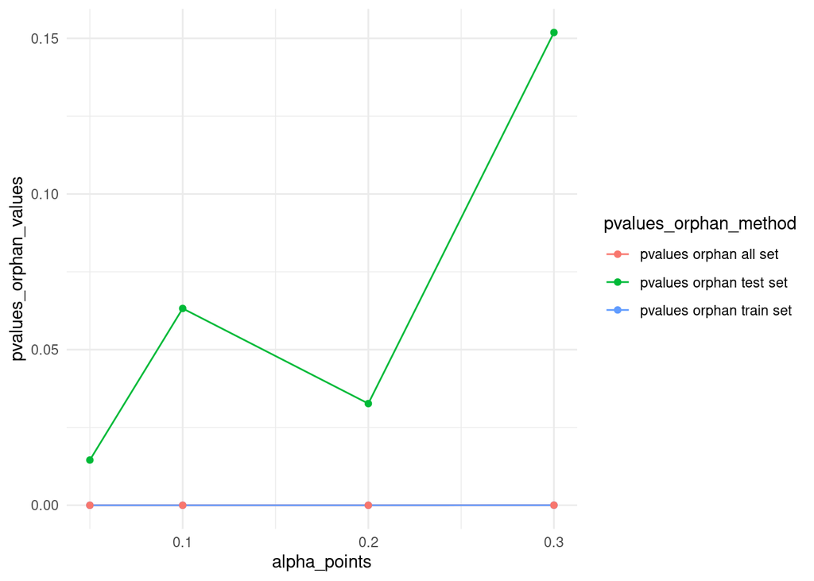

```r
pvalues_orphan_values<-c(train_orphan03$pvalue,train_orphan02$pvalue,train_orphan01$pvalue,train_orphan05$pvalue,
                      test_orphan03$pvalue,test_orphan02$pvalue,test_orphan01$pvalue,test_orphan05$pvalue,
                      all_orphan03$pvalue,all_orphan02$pvalue,all_orphan01$pvalue,all_orphan05$pvalue)

pvalues_orphan_method<-c(rep("pvalues orphan train set",4),rep("pvalues orphan test set",4),rep("pvalues orphan all set",4))


pvalues_orphan<-data.frame(alpha_points,pvalues_orphan_values,pvalues_orphan_method)
p_pvalues_orphan<-ggplot(data = pvalues_orphan, aes(x = alpha_points, y = pvalues_orphan_values,color= pvalues_orphan_method)) + geom_line()+geom_point()+theme_minimal()
p_pvalues_orphan+ ylim(0, max(pvalues_orphan_values))
```

## 4.4 Final plot comparing all models - Figure 4

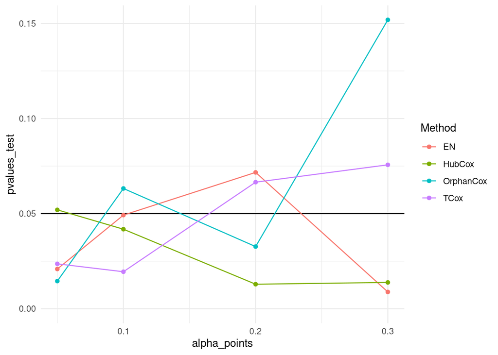

```r
alpha_points<-c(0.3, 0.2,0.1,0.05)

#TCox (exp(-w^3))
pvalues_twexp2_values_test<-c(test_twii03$pvalue,test_twii02$pvalue,test_twii01$pvalue,test_twii05$pvalue)

#EN
pvalues_en_test<-c(test_en03$pvalue,test_en02$pvalue,test_en01$pvalue,test_en05$pvalue)

#Hub
pvalues_hub_test<-c(test_hub03$pvalue,test_hub02$pvalue,test_hub01$pvalue,test_hub05$pvalue)

#Orphan
pvalues_orphan_test<-c(test_orphan03$pvalue,test_orphan02$pvalue,test_orphan01$pvalue,test_orphan05$pvalue)

pvalues_test<-c(pvalues_twexp2_values_test, pvalues_en_test, pvalues_hub_test, pvalues_orphan_test)

Method <-c(rep("TCox",4), rep("EN",4), rep("HubCox",4), rep("OrphanCox",4))

pvalues_test_data<-data.frame(alpha_points,pvalues_test,Method)

p_pvalues_test<-ggplot(data = pvalues_test_data, aes(x = alpha_points, y = pvalues_test,color= Method)) + geom_hline(yintercept=0.05) + geom_line()+geom_point()+theme_minimal()
p_pvalues_test+ ylim(0, max(pvalues_test))
```

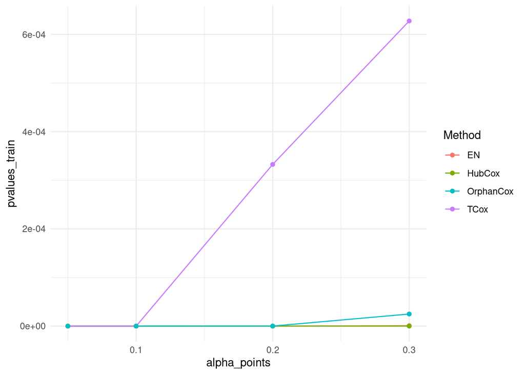

```r
alpha_points<-c(0.3, 0.2,0.1,0.05)

#TCox (exp(-w^3))
pvalues_twexp2_values_train<-c(train_twexp203$pvalue,train_twexp202$pvalue,train_twexp201$pvalue,train_twexp205$pvalue)

#EN
pvalues_en_train<-c(train_en03$pvalue,train_en02$pvalue,train_en01$pvalue,train_en05$pvalue)

#Hub
pvalues_hub_train<-c(train_hub03$pvalue,train_hub02$pvalue,train_hub01$pvalue,train_hub05$pvalue)

#Orphan
pvalues_orphan_train<-c(train_orphan03$pvalue,train_orphan02$pvalue,train_orphan01$pvalue,train_orphan05$pvalue)

pvalues_train<-c(pvalues_twexp2_values_train, pvalues_en_train, pvalues_hub_train, pvalues_orphan_train)

Method <-c(rep("TCox",4), rep("EN",4), rep("HubCox",4), rep("OrphanCox",4))

pvalues_train_data<-data.frame(alpha_points,pvalues_train,Method)

p_pvalues_train<-ggplot(data = pvalues_train_data, aes(x = alpha_points, y = pvalues_train,color= Method)) + geom_hline(yintercept=0.05) + geom_line()+geom_point()+theme_minimal()
p_pvalues_train+ ylim(0, max(pvalues_train))
```

# 5 CHAT tool

by all models

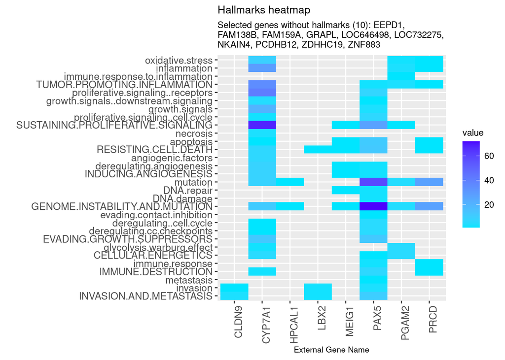

```r
genes <- tumorf[,c("CYP7A1","FAM159A","LOC732275","CLDN9","LBX2","MEIG1","PAX5","NKAIN4","ZDHHC19","GRAPL","PCDHB12","EEPD1","HPCAL1","PGAM2","ZNF883","FAM138B","LOC646498","PRCD")]

geneNames(names(genes)) %>% { hallmarks(.$external_gene_name)$heatmap} + theme(title = element_text(size=9),axis.text=element_text(size=10), axis.title=element_text(size=8))
```

genes selected only by:

EN

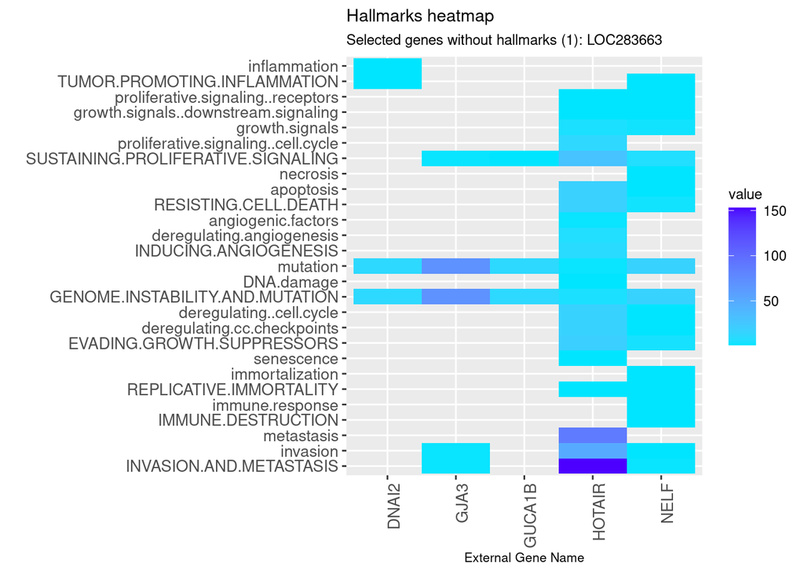

```r
genes <- tumorf[,c("HOTAIR","GJA3","LOC283663","DNAI2","NELF","GUCA1B")]

geneNames(names(genes)) %>% { hallmarks(.$external_gene_name)$heatmap} + theme(title = element_text(size=9),axis.text=element_text(size=10), axis.title=element_text(size=8))
```

glmSparseNet

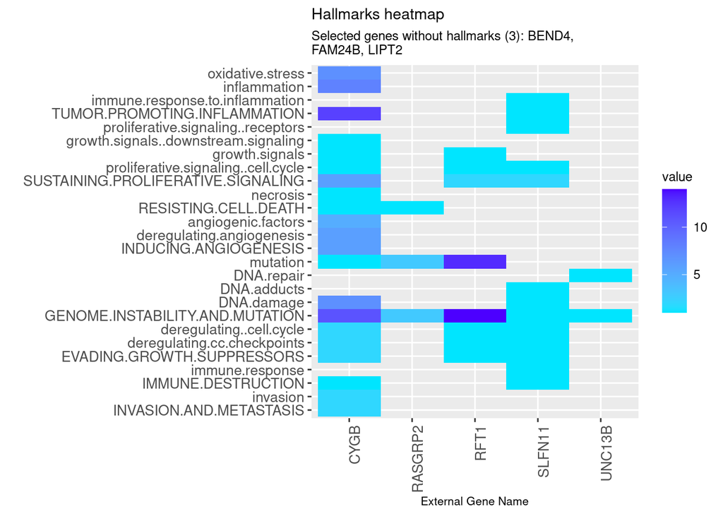

```r
genes <- tumorf[,c("CYGB","UNC13B","LIPT2","RFT1","BEND4","FAM24B","RASGRP2","SLFN11")]

geneNames(names(genes)) %>% { hallmarks(.$external_gene_name)$heatmap} + theme(title = element_text(size=9),axis.text=element_text(size=10), axis.title=element_text(size=8))
```

TCox

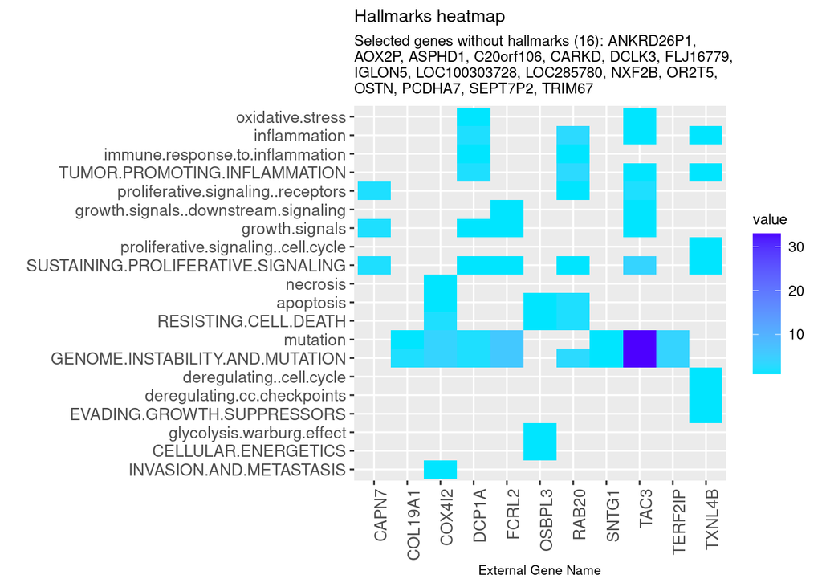

```r
genes <- tumorf[,c("ANKRD26P1","CARKD","IGLON5","OSTN","RAB20","TXNL4B","AOX2P","DCLK3","FCRL2","SEPT7P2","ASPHD1","COL19A1","DCP1A","FLJ16779","LOC100303728","PCDHA7","SNTG1","COX4I2","NXF2B","TAC3","C20orf106","LOC285780","OR2T5","TERF2IP","CAPN7","OSBPL3","TRIM67")]

geneNames(names(genes)) %>% { hallmarks(.$external_gene_name)$heatmap} + theme(title = element_text(size=9),axis.text=element_text(size=10), axis.title=element_text(size=8))
```

# 6 Differentially expressed genes

## 6.1 Early vs. advanced stage

```r
clinic$neoplasm_diseasestage[clinic$neoplasm_diseasestage == "stage ivb"] <- 4
clinic$neoplasm_diseasestage[clinic$neoplasm_diseasestage == "stage iva"] <- 4
clinic$neoplasm_diseasestage[clinic$neoplasm_diseasestage == "stage iv"] <- 4
clinic$neoplasm_diseasestage[clinic$neoplasm_diseasestage == "stage iiic"] <- 3
clinic$neoplasm_diseasestage[clinic$neoplasm_diseasestage == "stage iiib"] <- 3
clinic$neoplasm_diseasestage[clinic$neoplasm_diseasestage == "stage iiia"] <- 3
clinic$neoplasm_diseasestage[clinic$neoplasm_diseasestage == "stage iii"] <- 3
clinic$neoplasm_diseasestage[clinic$neoplasm_diseasestage == "stage iic"] <- 2
clinic$neoplasm_diseasestage[clinic$neoplasm_diseasestage == "stage iib"] <- 2
clinic$neoplasm_diseasestage[clinic$neoplasm_diseasestage == "stage iia"] <- 2
clinic$neoplasm_diseasestage[clinic$neoplasm_diseasestage == "stage ii"] <- 2
clinic$neoplasm_diseasestage[clinic$neoplasm_diseasestage == "stage ia"] <- 1
clinic$neoplasm_diseasestage[clinic$neoplasm_diseasestage == "stage i"] <- 1

pathology_stage <- as.data.frame(clinic$neoplasm_diseasestage)
pathology_stage$names <- rownames(clinic)
pathology_stage$names <- toupper(pathology_stage$names)
pathology_stage$names <- chartr('.', '-', pathology_stage$names)
pathology_stage <- na.omit(pathology_stage)
row.names(pathology_stage) <- pathology_stage$names
pathology_stage <- as.data.frame(pathology_stage)
pathology_stage$`clinic$neoplasm_diseasestage` <- as.numeric(pathology_stage$`clinic$neoplasm_diseasestage`)

pathology_stage$`clinic$neoplasm_diseasestage`[pathology_stage$`clinic$neoplasm_diseasestage` == "1"] <- "early"
pathology_stage$`clinic$neoplasm_diseasestage`[pathology_stage$`clinic$neoplasm_diseasestage` == "2"] <-  "early"
pathology_stage$`clinic$neoplasm_diseasestage`[pathology_stage$`clinic$neoplasm_diseasestage` == "3"] <-  "early"
pathology_stage$`clinic$neoplasm_diseasestage`[pathology_stage$`clinic$neoplasm_diseasestage` == "4"] <- "advanced"



all_data = merge(tumorf,pathology_stage,by="row.names")
#rownames(all_data) <- all_data$submitter_id

xdata <- apply(as.matrix(all_data[,2:20502]),2,as.numeric)
xdata <- xdata[ ,- as.numeric(which(apply(xdata, 2, var) == 0))]
xdata <- t(xdata)

group <- all_data$`clinic$neoplasm_diseasestage`
```

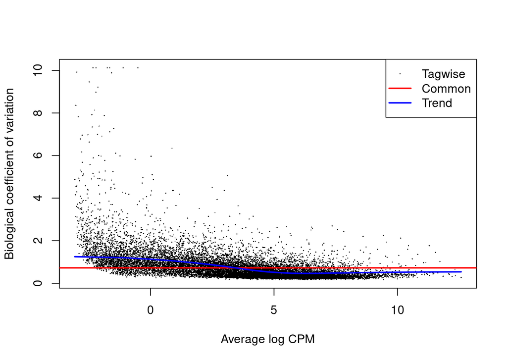

```r
y <- DGEList(counts=xdata,group=group)
#remove genes that are unexpressed or very lowly expressed in the samples
keep <- rowSums(cpm(y)>1) >= 2
y <- y[keep, , keep.lib.sizes=FALSE]

y <- calcNormFactors(y)
# plotMDS(y)

design <- model.matrix(~group)
y <- estimateDisp(y,design)
plotBCV(y)
```

```r
# y$samples
# levels(y$samples$group)
```

To perform quasi-likelihood F-tests (The quasi-likelihood method is highly recommended for differential expression analyses of bulk RNA-seq data as it gives stricter error rate control by accounting for the uncertainty in dispersion estimation)

```r
fit <- glmQLFit(y, design)

qlf <- glmQLFTest(fit,coef=2)


# lrt <- glmLRT(fit)
topTags(qlf)
```

```
## Coefficient:  groupearly
##                   logFC     logCPM        F       PValue          FDR
## XAGE1D        -7.278711 -1.2348223 608.8796 5.266627e-71 8.974859e-67
## CT45A4        -5.190992 -2.8256847 595.3811 4.237922e-70 3.546180e-66
## CT45A3        -7.247917 -1.5793655 592.8965 6.242909e-70 3.546180e-66
## DKFZp686A1627 -5.847695 -2.5227528 590.9097 8.516663e-70 3.628311e-66
## DCAF4L2       -6.633494 -2.0817666 588.1865 1.305114e-69 4.448089e-66
## MAGEA10       -6.258910 -2.1003651 551.9612 4.360032e-67 1.238322e-63
## CXorf49B      -8.160416  0.1161680 505.5592 1.098395e-63 2.673965e-60
## FOXR2         -4.804525 -2.8724963 477.0349 1.716385e-61 3.656115e-58
## CT45A1        -7.280180 -0.6235422 426.2823 2.264051e-57 4.286855e-54
## TUBA3C        -4.771858 -2.5453413 357.1792 3.014495e-51 5.137001e-48
```

```r
summary(decideTests(qlf))
```

```
##        groupearly
## Down          602
## NotSig      16079
## Up            360
```

```r
a <- qlf$table
a <- a[a$PValue < 0.05, ]

write.table(a, "tabela_genes_degs_earlyvsadv.csv", append = TRUE)
```

Plot log-fold change against log-counts per million, with DE genes highlighted:

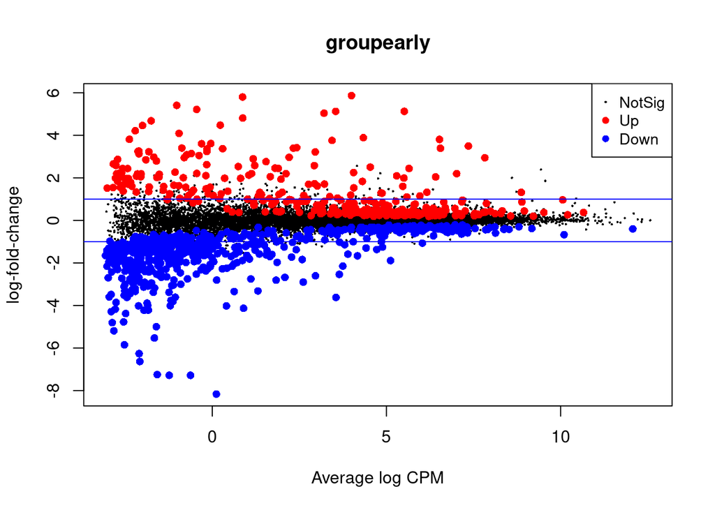

```r
plotMD(qlf)
abline(h=c(-1, 1), col="blue")
```

## 6.2 Tumor vs. normal

```r
# tumor 373
# normal 60
tumorf <- t(tumorf)
normalf <- t(normalf)
all = merge(tumorf,normalf,by="row.names")
rownames(all) <- all$Row.names

all <- all[,-1]
all <- t(all)
all <- as.data.frame(all)
all$type[1:433] <- "normal"
all$type[1:373] <- "tumor"


xdatadeg <- apply(as.matrix(all[,1:20501]),2,as.numeric)
xdatadeg <- xdatadeg[,apply(xdatadeg!=0, 2, all)]
xdatadeg <- t(xdatadeg)

group <- all$type
```

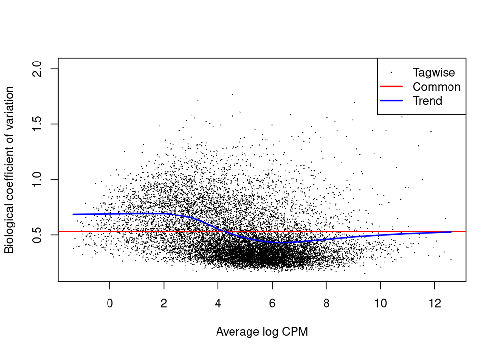

```r
y <- DGEList(counts=xdatadeg,group=group)
#remove genes that are unexpressed or very lowly expressed in the samples
keep <- rowSums(cpm(y)>1) >= 2
y <- y[keep, , keep.lib.sizes=FALSE]

y <- calcNormFactors(y)
# plotMDS(y)

design <- model.matrix(~group)
y <- estimateDisp(y,design)
plotBCV(y)
```

```r
# y$samples
# levels(y$samples$group)
```

To perform quasi-likelihood F-tests (The quasi-likelihood method is highly recommended for differential expression analyses of bulk RNA-seq data as it gives stricter error rate control by accounting for the uncertainty in dispersion estimation)

```r
fit <- glmQLFit(y, design)

qlf <- glmQLFTest(fit,coef=2)


# lrt <- glmLRT(fit)
topTags(qlf)
```

```
## Coefficient:  grouptumor
##             logFC    logCPM         F        PValue           FDR
## UGP2    -1.907729 7.2692269 1066.7289 4.101999e-119 5.450736e-115
## CLEC3B  -3.830019 3.9500075  880.0177 1.472141e-106 9.780906e-103
## CUBN    -5.121942 1.8001048  864.0506 2.105275e-105 9.324966e-102
## A1BG    -4.951522 2.7322544  854.6489 1.023940e-104 3.401530e-101
## PHLPP2  -2.385443 5.0304506  762.5613  1.040458e-97  2.765122e-94
## SULT1A2 -3.916172 2.2476161  756.2584  3.283824e-97  7.272575e-94
## KCNIP4  -2.696053 0.7653609  721.3317  2.144063e-94  4.070044e-91
## PEX26   -1.855932 5.3462240  694.9992  3.238848e-92  5.379727e-89
## ZNF575  -2.160721 1.9742580  687.2304  1.455565e-91  2.149060e-88
## PLCD1   -2.225580 4.6921304  668.6268  5.552143e-90  7.377688e-87
```

```r
summary(decideTests(qlf))
```

```
##        grouptumor
## Down         4639
## NotSig       3056
## Up           5593
```

```r
b <- qlf$table
b <- b[a$PValue < 0.05, ]

write.table(b, "tabela_genes_degs_tumorvsnorm.csv", append = TRUE)
```

Plot log-fold change against log-counts per million, with DE genes highlighted:

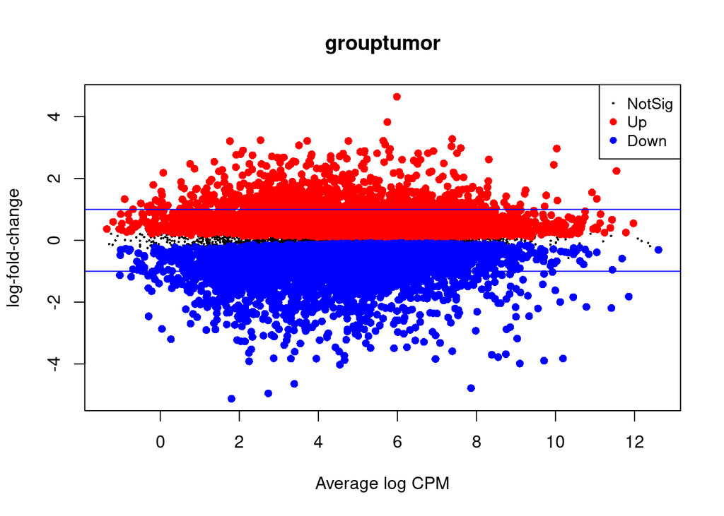

```r
plotMD(qlf)
abline(h=c(-1, 1), col="blue")
```

## 6.3 Tumor vs. normal genes selected by all models

```r
# tumor 373
# normal 60

few <- all[,c("CYP7A1",
"FAM159A",
"LOC732275",
"CLDN9",
"LBX2",
"MEIG1",
"PAX5",
"NKAIN4",
"ZDHHC19",
"GRAPL",
"PCDHB12",
"EEPD1",
"HPCAL1",
"PGAM2",
"ZNF883",
"FAM138B",
"LOC646498",
"PRCD","type")]

xdatadeg <- apply(as.matrix(few[,1:18]),2,as.numeric)
xdatadeg <- t(xdatadeg)

group <- all$type
```

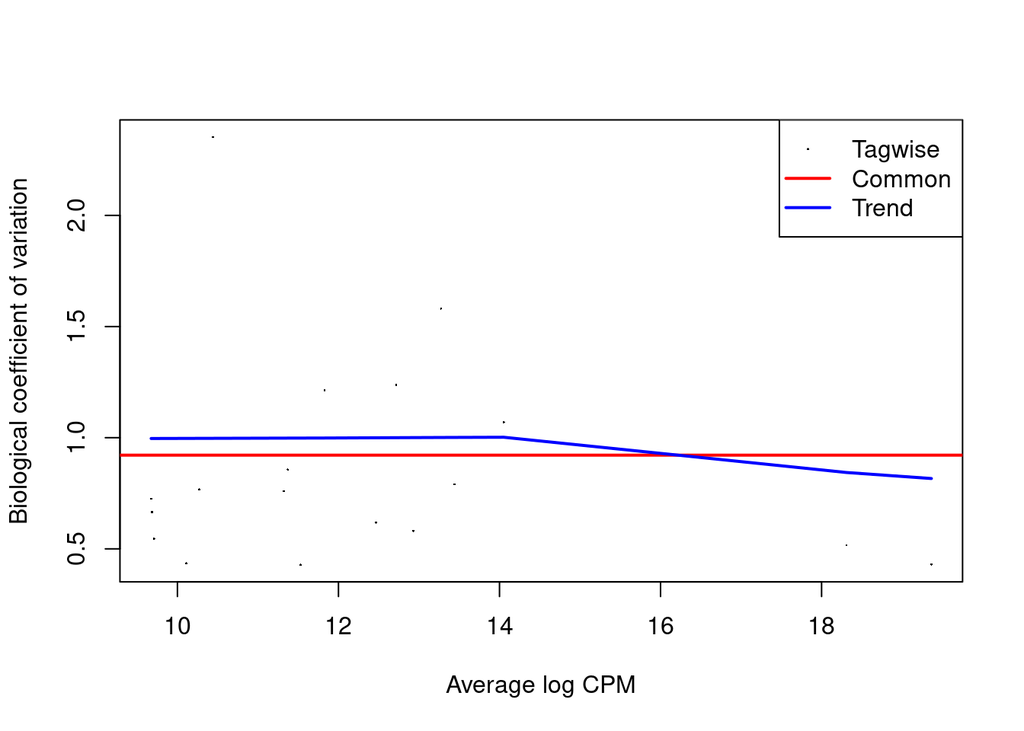

```r
y <- DGEList(counts=xdatadeg,group=group)
#remove genes that are unexpressed or very lowly expressed in the samples
keep <- rowSums(cpm(y)>1) >= 2
y <- y[keep, , keep.lib.sizes=FALSE]

y <- calcNormFactors(y)
# plotMDS(y)

design <- model.matrix(~group)
y <- estimateDisp(y,design)
plotBCV(y)
```

```r
# y$samples
# levels(y$samples$group)
```

```r
fit <- glmQLFit(y, design)

qlf <- glmQLFTest(fit,coef=2)


# lrt <- glmLRT(fit)
topTags(qlf)
```

```
## Coefficient:  grouptumor
##              logFC   logCPM        F       PValue          FDR
## PRCD    -0.9164964 11.52905 65.65138 5.480847e-15 9.865525e-14
## LBX2     1.1617787 12.46498 55.69423 4.644110e-13 4.179699e-12
## EEPD1    0.8073150 18.30913 51.18356 3.589396e-12 2.153638e-11
## PAX5    -1.8627698 13.27415 43.30143 1.350442e-10 6.076989e-10
## ZDHHC19 -1.2580156 10.27088 40.31242 5.447264e-10 1.961015e-09
## FAM159A -1.0008112 11.37126 30.59998 5.480797e-08 1.644239e-07
## CLDN9    1.3526544 14.05259 27.23531 2.793765e-07 7.183967e-07
## CYP7A1  -1.5118019 10.43878 26.68755 3.648163e-07 8.208366e-07
## PGAM2   -0.4782448 12.93011 14.72795 1.425790e-04 2.851580e-04
## NKAIN4  -0.7753835 11.82751 10.16699 1.532944e-03 2.759300e-03
```

```r
summary(decideTests(qlf))
```

```
##        grouptumor
## Down            9
## NotSig          6
## Up              3
```

```r
decideTests(qlf)
```

```
## TestResults matrix
##           grouptumor
## CYP7A1            -1
## FAM159A           -1
## LOC732275          0
## CLDN9              1
## LBX2               1
## 13 more rows ...
```

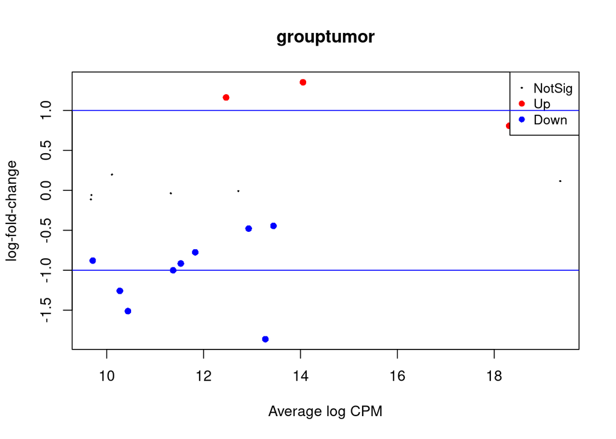

```r
plotMD(qlf)
abline(h=c(-1, 1), col="blue")
```